# Project 3 - Date Set Creation

Data Management Using SAS

Author

Sean Vieau

Published

October 28, 2024

# Introduction

This is part three of the main project for BIOS 6680: Data Management Using SAS, in which we plan and carry out data management activities including data cleaning/quality assurance, data documentation, and analytic data set creation. A key goal of this project is to demonstrate reproducible research and reporting.

**The purpose of this project is to write a SAS program to create a combined analysis data set.**

# Background

The Behavioral Risk Factor Surveillance System (BRFSS) is a collaborative database of ongoing health related telephone surveys that collect data on risk behaviors, chronic health conditions, health care access, and use of preventive services from adults (>= 18 years) in all 50 states in the U.S. and additional territories. The objective of the BRFSS is to collect uniform state-specific data on health-related outcomes and behaviors relating to the leading causes of death and disability in the US. This is real, patient level data.

## Email from Investigator

[figure not shown]

#### Main Research Question

The researcher’s main question is whether there is a significant difference in BMI between California and North Carolina.

#### Desired Data Set

They are only interested in including the following states: California, Colorado, Connecticut, Delaware, New Mexico, North Carolina, and West Virginia.

The investigator has asked us to create and merge the following data sets:

[figure not shown]

# Step 0: Connect to SAS

This document was created in RStudio with Quarto.

To code in SAS we first need to connect RStudio to the SAS server.

```r
# This code connects to SAS On Demand
library(configSAS)
configSAS::set_sas_engine()
```

```
Using SAS Config named: oda
SAS Connection established. Subprocess id is 36512
```

````r
#  This code allows you to run ```{sas}``` chunks
sas = knitr::opts_chunk$get("sas")
````

# Step 1: Create Libraries

Then we will create the necessary libraries.

```sas
* Set Courseroot;
%LET CourseRoot = /home/u63376223/sasuser.v94/Data Management Using SAS;

* Create libraries;
LIBNAME Source "&CourseRoot/BRFSS/Data/1_Source";
LIBNAME Impt "&CourseRoot/BRFSS/Data/2_Import";
```

# Step 2: Read In Data

Here we will import the data sets.

**Reference Table**

#### Import and Transpose Data

```sas
* Import the reference table;
TITLE "Reference Table";
DATA Impt.ref_table;
    SET "&CourseRoot/BRFSS/Data/1_Source/ref_table (1).sas7bdat";
RUN;

* Transpose it to wideform;
PROC TRANSPOSE DATA = Impt.ref_table
    OUT = Impt.ref_table_long;
    VAR COL1--COL29803;
    RUN;

* Process the transposed data (drop out the _NAME_ coulumn);
DATA Impt.ref_table_long;
    SET Impt.ref_table_long;
    DROP _NAME_;
    RUN;
```

#### View Data

```sas
* Check contents to ensure correct data types;
ODS SELECT VARIABLES;
PROC CONTENTS DATA = Impt.ref_table_long;
    RUN;

* Visualize data set;
PROC PRINT DATA = Impt.ref_table_long (OBS = 10);
    RUN;
```

**lst**

<!DOCTYPE html>

Reference Table

The CONTENTS Procedure

| Alphabetic List of Variables and Attributes # | Alphabetic List of Variables and Attributes Variable | Alphabetic List of Variables and Attributes Type | Alphabetic List of Variables and Attributes Len | Alphabetic List of Variables and Attributes Label |
| --- | --- | --- | --- | --- |
| 7 | DISPCODE | Char | 200 | FINAL DISPOSITION |
| 4 | IDAY | Char | 200 | INTERVIEW DAY |
| 3 | IMONTH | Char | 200 | INTERVIEW MONTH |
| 5 | IYEAR | Char | 200 | INTERVIEW YEAR |
| 2 | SEQNO | Char | 200 | ANNUAL SEQUENCE NUMBER |
| 1 | id | Char | 200 |  |
| 6 | state | Char | 200 |  |

Reference Table

| Obs | id | SEQNO | IMONTH | IDAY | IYEAR | state | DISPCODE |
| --- | --- | --- | --- | --- | --- | --- | --- |
| 1 | 6_2022000075 | 2022000075 | 07 | 05 | 2022 | 6 | 1100 |
| 2 | 6_2022000076 | 2022000076 | 06 | 28 | 2022 | 6 | 1100 |
| 3 | 6_2022000077 | 2022000077 | 06 | 27 | 2022 | 6 | 1100 |
| 4 | 6_2022000078 | 2022000078 | 06 | 29 | 2022 | 6 | 1100 |
| 5 | 6_2022000079 | 2022000079 | 07 | 05 | 2022 | 6 | 1100 |
| 6 | 6_2022000080 | 2022000080 | 07 | 05 | 2022 | 6 | 1200 |
| 7 | 6_2022000081 | 2022000081 | 07 | 09 | 2022 | 6 | 1100 |
| 8 | 6_2022000082 | 2022000082 | 06 | 28 | 2022 | 6 | 1100 |
| 9 | 6_2022000083 | 2022000083 | 07 | 04 | 2022 | 6 | 1100 |
| 10 | 6_2022000084 | 2022000084 | 07 | 09 | 2022 | 6 | 1100 |

**log**

```
9                                                          The SAS System                      Friday, December 19, 2025 03:04:00 AM

66         ods listing close;ods html5 (id=saspy_internal) file=_tomods1 options(bitmap_mode='inline') device=svg style=HTMLBlue;
66       ! ods graphics on / outputfmt=png;
67
68
69         * Check contents to ensure correct data types;
70         ODS SELECT VARIABLES;
71         PROC CONTENTS DATA = Impt.ref_table_long;
72          RUN;
73
74         * Visualize data set;
75         PROC PRINT DATA = Impt.ref_table_long (OBS = 10);
76          RUN;
77
78
79         ods html5 (id=saspy_internal) close;ods listing;
80
10                                                         The SAS System                      Friday, December 19, 2025 03:04:00 AM

81
```

The reference table looks good and has been transposed correctly.

Top of Tabset

**Demographics**

#### Import Data

```sas
* Import demographics data set;
TITLE "Demographics";
PROC IMPORT
        DATAFILE =  "&CourseRoot/BRFSS/Data/1_Source/demographics (2).xlsx"
        OUT     =   Impt.Demographics
        DBMS    =   XLSX
        REPLACE;
RUN;
```

#### View Data

```sas
* Check contents to ensure correct data types;
ODS SELECT VARIABLES;
PROC CONTENTS DATA = Impt.DEMOGRAPHICS;
    RUN;

* Visualize data set;
PROC PRINT DATA = Impt.Demographics (OBS = 10);
    RUN;
```

**lst**

<!DOCTYPE html>

Demographics

The CONTENTS Procedure

| Alphabetic List of Variables and Attributes # | Alphabetic List of Variables and Attributes Variable | Alphabetic List of Variables and Attributes Type | Alphabetic List of Variables and Attributes Len | Alphabetic List of Variables and Attributes Format | Alphabetic List of Variables and Attributes Informat | Alphabetic List of Variables and Attributes Label |
| --- | --- | --- | --- | --- | --- | --- |
| 10 | BLIND | Num | 8 | BEST. |  | BLIND |
| 4 | CHECKUP1 | Num | 8 | BEST. |  | CHECKUP1 |
| 9 | DEAF | Num | 8 | BEST. |  | DEAF |
| 11 | DECIDE | Num | 8 | BEST. |  | DECIDE |
| 14 | DIFFALON | Num | 8 | BEST. |  | DIFFALON |
| 13 | DIFFDRES | Num | 8 | BEST. |  | DIFFDRES |
| 12 | DIFFWALK | Num | 8 | BEST. |  | DIFFWALK |
| 6 | EDUCA | Num | 8 | BEST. |  | EDUCA |
| 7 | EMPLOY1 | Num | 8 | BEST. |  | EMPLOY1 |
| 8 | INCOME3 | Num | 8 | BEST. |  | INCOME3 |
| 5 | MARITAL | Num | 8 | BEST. |  | MARITAL |
| 3 | MEDCOST1 | Num | 8 | BEST. |  | MEDCOST1 |
| 2 | PERSDOC3 | Num | 8 | BEST. |  | PERSDOC3 |
| 1 | PRIMINSR | Num | 8 | BEST. |  | PRIMINSR |
| 15 | TRNSGNDR | Num | 8 | BEST. |  | TRNSGNDR |
| 19 | _AGEG5YR | Num | 8 | BEST. |  | _AGEG5YR |
| 17 | _HISPANC | Num | 8 | BEST. |  | _HISPANC |
| 16 | _PRACE2 | Num | 8 | BEST. |  | _PRACE2 |
| 18 | _SEX | Num | 8 | BEST. |  | _SEX |
| 20 | seqno | Char | 12 | $12. | $12. | seqno |

Demographics

| Obs | PRIMINSR | PERSDOC3 | MEDCOST1 | CHECKUP1 | MARITAL | EDUCA | EMPLOY1 | INCOME3 | DEAF | BLIND | DECIDE | DIFFWALK | DIFFDRES | DIFFALON | TRNSGNDR | _PRACE2 | _HISPANC | _SEX | _AGEG5YR | seqno |
| --- | --- | --- | --- | --- | --- | --- | --- | --- | --- | --- | --- | --- | --- | --- | --- | --- | --- | --- | --- | --- |
| 1 | 3 | 1 | 2 | 1 | 3 | 5 | 7 | 8 | 2 | 2 | 2 | 2 | 2 | 2 | . | 1 | 2 | 2 | 11 | 202-200-0075 |
| 2 | 1 | 1 | 2 | 1 | 1 | 6 | 1 | 9 | 2 | 2 | 2 | 2 | 2 | 2 | . | 1 | 1 | 1 | 5 | 202-200-0076 |
| 3 | 3 | 1 | 2 | 2 | 3 | 6 | 2 | 8 | 2 | 2 | 2 | 2 | 2 | 2 | . | 1 | 2 | 2 | 12 | 202-200-0077 |
| 4 | 10 | 3 | 2 | 1 | 2 | 6 | 7 | 6 | 2 | 1 | 2 | 2 | 2 | 2 | . | 2 | 2 | 2 | 13 | 202-200-0078 |
| 5 | 3 | 1 | 2 | 1 | 1 | 6 | 7 | 99 | 2 | 1 | 2 | 2 | 2 | 2 | . | 1 | 2 | 1 | 12 | 202-200-0079 |
| 6 | 3 | 1 | 2 | 1 | 1 | 6 | 9 | 99 | 2 | 2 | 2 | 2 | 2 | 2 | . | 4 | 2 | 2 | 14 | 202-200-0080 |
| 7 | 3 | 2 | 2 | 1 | 2 | 6 | 7 | 4 | 2 | 2 | 2 | 1 | 2 | 2 | . | 1 | 2 | 2 | 13 | 202-200-0081 |
| 8 | 9 | 2 | 2 | 1 | 1 | 4 | 5 | 6 | 2 | 2 | 2 | 2 | 2 | 2 | . | 1 | 2 | 2 | 8 | 202-200-0082 |
| 9 | 3 | 3 | 2 | 3 | 1 | 6 | 7 | 77 | 2 | 2 | 2 | 2 | 2 | 2 | . | 1 | 2 | 1 | 11 | 202-200-0083 |
| 10 | 3 | 1 | 2 | 1 | 5 | 6 | 7 | 3 | 2 | 2 | 2 | 2 | 2 | 2 | . | 1 | 2 | 2 | 11 | 202-200-0084 |

**log**

```
13                                                         The SAS System                      Friday, December 19, 2025 03:04:00 AM

101        ods listing close;ods html5 (id=saspy_internal) file=_tomods1 options(bitmap_mode='inline') device=svg style=HTMLBlue;
101      ! ods graphics on / outputfmt=png;
102
103        * Check contents to ensure correct data types;
104        ODS SELECT VARIABLES;
105        PROC CONTENTS DATA = Impt.DEMOGRAPHICS;
106         RUN;
107
108        * Visualize data set;
109        PROC PRINT DATA = Impt.Demographics (OBS = 10);
110         RUN;
111
112
113        ods html5 (id=saspy_internal) close;ods listing;
114
14                                                         The SAS System                      Friday, December 19, 2025 03:04:00 AM

115
```

All Demographics variables are the correct length and type.

Top of Tabset

**Outcomes**

#### Import Data

```sas
* Import the dataset;
TITLE "Outcomes";
PROC IMPORT DATAFILE="&CourseRoot/BRFSS/Data/1_Source/outcomes (1).csv"
            OUT=Impt.Outcomes
            DBMS=CSV
            REPLACE;
     GETNAMES=YES;
     GUESSINGROWS=MAX; /* Ensures that SAS scans more rows to determine the correct data types */
     RUN;
```

#### View Data

```sas
* Check contents to ensure correct data types;
ODS SELECT VARIABLES;
PROC CONTENTS DATA = Impt.Outcomes;
    RUN;

* Examine data;
PROC PRINT DATA = Impt.Outcomes (OBS = 10);
  RUN;
```

**lst**

<!DOCTYPE html>

Outcomes

The CONTENTS Procedure

| Alphabetic List of Variables and Attributes # | Alphabetic List of Variables and Attributes Variable | Alphabetic List of Variables and Attributes Type | Alphabetic List of Variables and Attributes Len | Alphabetic List of Variables and Attributes Format | Alphabetic List of Variables and Attributes Informat |
| --- | --- | --- | --- | --- | --- |
| 7 | ADDEPEV3 | Num | 8 | BEST12. | BEST32. |
| 4 | ASTHMA3 | Num | 8 | BEST12. | BEST32. |
| 5 | ASTHNOW | Num | 8 | BEST12. | BEST32. |
| 6 | CHCCOPD3 | Num | 8 | BEST12. | BEST32. |
| 15 | CNCRAGE | Num | 8 | BEST12. | BEST32. |
| 14 | CNCRDIFF | Num | 8 | BEST12. | BEST32. |
| 16 | CNCRTYP2 | Num | 8 | BEST12. | BEST32. |
| 11 | COVIDPOS | Num | 8 | BEST12. | BEST32. |
| 13 | COVIDPRM | Num | 8 | BEST12. | BEST32. |
| 12 | COVIDSMP | Num | 8 | BEST12. | BEST32. |
| 3 | CVDCRHD4 | Num | 8 | BEST12. | BEST32. |
| 2 | CVDINFR4 | Num | 8 | BEST12. | BEST32. |
| 8 | DIABETE4 | Num | 8 | BEST12. | BEST32. |
| 18 | EMTSUPRT | Num | 8 | BEST12. | BEST32. |
| 10 | HEIGHT3 | Num | 8 | BEST12. | BEST32. |
| 17 | LSATISFY | Num | 8 | BEST12. | BEST32. |
| 19 | SDHISOLT | Num | 8 | BEST12. | BEST32. |
| 1 | SEQNO | Num | 8 | BEST12. | BEST32. |
| 9 | WEIGHT2 | Num | 8 | BEST12. | BEST32. |

Outcomes

| Obs | SEQNO | CVDINFR4 | CVDCRHD4 | ASTHMA3 | ASTHNOW | CHCCOPD3 | ADDEPEV3 | DIABETE4 | WEIGHT2 | HEIGHT3 | COVIDPOS | COVIDSMP | COVIDPRM | CNCRDIFF | CNCRAGE | CNCRTYP2 | LSATISFY | EMTSUPRT | SDHISOLT |
| --- | --- | --- | --- | --- | --- | --- | --- | --- | --- | --- | --- | --- | --- | --- | --- | --- | --- | --- | --- |
| 1 | 2022000075 | 2 | 2 | 2 | . | 2 | 2 | 3 | 148 | 503 | 2 | . | . | . | . | . | 2 | 3 | 4 |
| 2 | 2022000076 | 2 | 2 | 2 | . | 2 | 2 | 3 | 190 | 600 | 2 | . | . | . | . | . | 2 | 2 | 5 |
| 3 | 2022000077 | 2 | 2 | 1 | 2 | 2 | 2 | 3 | 123 | 504 | 2 | . | . | . | . | . | 1 | 1 | 4 |
| 4 | 2022000078 | 2 | 2 | 2 | . | 2 | 2 | 3 | 160 | 509 | 2 | . | . | . | . | . | 2 | 5 | 5 |
| 5 | 2022000079 | 2 | 2 | 2 | . | 2 | 2 | 4 | 145 | 508 | 2 | . | . | . | . | . | 2 | 2 | 3 |
| 6 | 2022000080 | 2 | 2 | 2 | . | 2 | 2 | 3 | 7777 | 7777 | 2 | . | . | . | . | . | 2 | 3 | 3 |
| 7 | 2022000081 | 1 | 2 | 2 | . | 2 | 2 | 3 | 130 | 508 | 2 | . | . | . | . | . | 2 | 2 | 4 |
| 8 | 2022000082 | 2 | 1 | 2 | . | 1 | 1 | 3 | 150 | 506 | 1 | 1 | 1 | . | . | . | 2 | 2 | 4 |
| 9 | 2022000083 | 2 | 2 | 2 | . | 2 | 2 | 3 | 192 | 602 | 1 | 2 | . | . | . | . | 2 | 1 | 3 |
| 10 | 2022000084 | 2 | 2 | 1 | 1 | 2 | 1 | 3 | 9999 | 502 | 2 | . | . | . | . | . | 2 | 4 | 2 |

**log**

```
17                                                         The SAS System                      Friday, December 19, 2025 03:04:00 AM

208        ods listing close;ods html5 (id=saspy_internal) file=_tomods1 options(bitmap_mode='inline') device=svg style=HTMLBlue;
208      ! ods graphics on / outputfmt=png;
209
210        * Check contents to ensure correct data types;
211        ODS SELECT VARIABLES;
212        PROC CONTENTS DATA = Impt.Outcomes;
213         RUN;
214
215        * Examine data;
216        PROC PRINT DATA = Impt.Outcomes (OBS = 10);
217          RUN;
218
219
220        ods html5 (id=saspy_internal) close;ods listing;
221
18                                                         The SAS System                      Friday, December 19, 2025 03:04:00 AM

222
```

All Outcomes variables are the correct length and type.

Top of Tabset

**Risk Factors**

#### Import Data

```sas
* Import risk factors;
TITLE "Risk Factors";
PROC IMPORT
        DATAFILE =  "&CourseRoot/BRFSS/Data/1_Source/riskfactors (1).xlsx"
        OUT     =   Impt.Risk
        DBMS    =   XLSX
        REPLACE ;
    RUN;
```

#### View Data

```sas
* Check contents to ensure correct data types;
ODS SELECT VARIABLES;
PROC CONTENTS DATA = Impt.Risk;
    RUN;

* Visualize data set;
PROC PRINT DATA = Impt.Risk (OBS = 10);
    RUN;
```

**lst**

<!DOCTYPE html>

Risk Factors

The CONTENTS Procedure

| Alphabetic List of Variables and Attributes # | Alphabetic List of Variables and Attributes Variable | Alphabetic List of Variables and Attributes Type | Alphabetic List of Variables and Attributes Len | Alphabetic List of Variables and Attributes Format | Alphabetic List of Variables and Attributes Informat | Alphabetic List of Variables and Attributes Label |
| --- | --- | --- | --- | --- | --- | --- |
| 13 | ALCDAY4 | Num | 8 | BEST. |  | ALCDAY4 |
| 14 | AVEDRNK3 | Num | 8 | BEST. |  | AVEDRNK3 |
| 19 | COVIDFS1 | Num | 8 | BEST. |  | COVIDFS1 |
| 18 | COVIDNU1 | Num | 8 | BEST. |  | COVIDNU1 |
| 20 | COVIDSE1 | Num | 8 | BEST. |  | COVIDSE1 |
| 17 | COVIDVA1 | Num | 8 | BEST. |  | COVIDVA1 |
| 15 | DRNK3GE5 | Num | 8 | BEST. |  | DRNK3GE5 |
| 9 | ECIGNOW2 | Num | 8 | BEST. |  | ECIGNOW2 |
| 4 | EXERANY2 | Num | 8 | BEST. |  | EXERANY2 |
| 1 | GENHLTH | Num | 8 | BEST. |  | GENHLTH |
| 10 | LCSFIRST | Num | 8 | BEST. |  | LCSFIRST |
| 11 | LCSLAST | Num | 8 | BEST. |  | LCSLAST |
| 12 | LCSNUMCG | Num | 8 | BEST. |  | LCSNUMCG |
| 21 | MARIJAN1 | Num | 8 | BEST. |  | MARIJAN1 |
| 25 | MARJDAB | Num | 8 | BEST. |  | MARJDAB |
| 23 | MARJEAT | Num | 8 | BEST. |  | MARJEAT |
| 26 | MARJOTHR | Num | 8 | BEST. |  | MARJOTHR |
| 22 | MARJSMOK | Num | 8 | BEST. |  | MARJSMOK |
| 24 | MARJVAPE | Num | 8 | BEST. |  | MARJVAPE |
| 16 | MAXDRNKS | Num | 8 | BEST. |  | MAXDRNKS |
| 3 | MENTHLTH | Num | 8 | BEST. |  | MENTHLTH |
| 2 | PHYSHLTH | Num | 8 | BEST. |  | PHYSHLTH |
| 5 | SLEPTIM1 | Num | 8 | BEST. |  | SLEPTIM1 |
| 7 | SMOKDAY2 | Num | 8 | BEST. |  | SMOKDAY2 |
| 6 | SMOKE100 | Num | 8 | BEST. |  | SMOKE100 |
| 8 | USENOW3 | Num | 8 | BEST. |  | USENOW3 |
| 27 | id | Char | 13 | $13. | $13. | id |

Risk Factors

| Obs | GENHLTH | PHYSHLTH | MENTHLTH | EXERANY2 | SLEPTIM1 | SMOKE100 | SMOKDAY2 | USENOW3 | ECIGNOW2 | LCSFIRST | LCSLAST | LCSNUMCG | ALCDAY4 | AVEDRNK3 | DRNK3GE5 | MAXDRNKS | COVIDVA1 | COVIDNU1 | COVIDFS1 | COVIDSE1 | MARIJAN1 | MARJSMOK | MARJEAT | MARJVAPE | MARJDAB | MARJOTHR | id |
| --- | --- | --- | --- | --- | --- | --- | --- | --- | --- | --- | --- | --- | --- | --- | --- | --- | --- | --- | --- | --- | --- | --- | --- | --- | --- | --- | --- |
| 1 | 2 | 88 | 88 | 2 | 8 | 2 | . | 3 | 4 | . | . | . | 888 | . | . | . | . | . | . | . | . | . | . | . | . | . | 1_2022000001 |
| 2 | 1 | 88 | 88 | 2 | 6 | 2 | . | 3 | 1 | . | . | . | 888 | . | . | . | . | . | . | . | . | . | . | . | . | . | 1_2022000002 |
| 3 | 2 | 2 | 3 | 1 | 5 | 2 | . | 3 | 1 | . | . | . | 888 | . | . | . | . | . | . | . | . | . | . | . | . | . | 1_2022000003 |
| 4 | 1 | 88 | 88 | 1 | 7 | 1 | 2 | 3 | 1 | 17 | 999 | 2 | 888 | . | . | . | . | . | . | . | . | . | . | . | . | . | 1_2022000004 |
| 5 | 4 | 2 | 88 | 1 | 9 | 2 | . | 3 | 1 | . | . | . | 203 | 2 | 88 | 2 | . | . | . | . | . | . | . | . | . | . | 1_2022000005 |
| 6 | 5 | 1 | 88 | 2 | 7 | 2 | . | 3 | 1 | . | . | . | 888 | . | . | . | . | . | . | . | . | . | . | . | . | . | 1_2022000006 |
| 7 | 2 | 88 | 88 | 1 | 7 | 1 | 3 | 3 | 1 | 16 | 58 | 35 | 205 | 2 | 88 | 2 | . | . | . | . | . | . | . | . | . | . | 1_2022000007 |
| 8 | 3 | 88 | 88 | 2 | 8 | 2 | . | 3 | 1 | . | . | . | 888 | . | . | . | . | . | . | . | . | . | . | . | . | . | 1_2022000008 |
| 9 | 3 | 88 | 88 | 1 | 6 | 1 | 3 | 3 | 4 | 20 | 21 | 5 | 888 | . | . | . | . | . | . | . | . | . | . | . | . | . | 1_2022000009 |
| 10 | 3 | 1 | 88 | 1 | 7 | 2 | . | 3 | 1 | . | . | . | 201 | 1 | 88 | 1 | . | . | . | . | . | . | . | . | . | . | 1_2022000010 |

**log**

```
21                                                         The SAS System                      Friday, December 19, 2025 03:04:00 AM

242        ods listing close;ods html5 (id=saspy_internal) file=_tomods1 options(bitmap_mode='inline') device=svg style=HTMLBlue;
242      ! ods graphics on / outputfmt=png;
243
244        * Check contents to ensure correct data types;
245        ODS SELECT VARIABLES;
246        PROC CONTENTS DATA = Impt.Risk;
247         RUN;
248
249        * Visualize data set;
250        PROC PRINT DATA = Impt.Risk (OBS = 10);
251         RUN;
252
253
254        ods html5 (id=saspy_internal) close;ods listing;
255
22                                                         The SAS System                      Friday, December 19, 2025 03:04:00 AM

256
```

All Risk Factors variables are the correct length and type.

Top of Tabset

# Step 3: Create Demographics Data Set

**Race**

#### Create Format

```sas
* Create FORMAT for race;
TITLE "Demographics: Race";
PROC FORMAT;
    VALUE RaceCd
            1 = "Non-Hispanic White"
            2 = "Non-Hispanic Black"
            3 = "Non-Hispanic American Indian or Alaskan Native"
            4 = "Hispanic"
            5 = "Other";
    RUN;
```

#### Create Variable

```sas
* Use boolean logic to create RaceCd variable per PI specifications;
DATA Impt.Demographics;
    SET Impt.Demographics;
        IF _PRACE2 = .                       THEN RaceCd = .;
        ELSE IF _PRACE2 = 1 AND _HISPANC = 2 THEN RaceCd = 1;
        ELSE IF _PRACE2 = 2 AND _HISPANC = 2 THEN RaceCd = 2;
        ELSE IF _PRACE2 = 3 AND _HISPANC = 2 THEN RaceCd = 3;
        ELSE IF                 _HISPANC = 1 THEN RaceCd = 4;
        ELSE                                      RaceCd = 5;
    ATTRIB RaceCd LABEL = "Race" FORMAT = RaceCd.;
    RUN;
```

#### Double Check for Correct Assignment

```sas
* Double check for correct assignment;
PROC PRINT DATA = Impt.Demographics (OBS = 10);
    VAR _PRACE2 _HISPANC RaceCd;
    FORMAT RaceCd RaceCd.;
    RUN;
```

**lst**

<!DOCTYPE html>

Demographics: Race

| Obs | _PRACE2 | _HISPANC | RaceCd |
| --- | --- | --- | --- |
| 1 | 1 | 2 | Non-Hispanic White |
| 2 | 1 | 1 | Hispanic |
| 3 | 1 | 2 | Non-Hispanic White |
| 4 | 2 | 2 | Non-Hispanic Black |
| 5 | 1 | 2 | Non-Hispanic White |
| 6 | 4 | 2 | Other |
| 7 | 1 | 2 | Non-Hispanic White |
| 8 | 1 | 2 | Non-Hispanic White |
| 9 | 1 | 2 | Non-Hispanic White |
| 10 | 1 | 2 | Non-Hispanic White |

**log**

```
27                                                         The SAS System                      Friday, December 19, 2025 03:04:00 AM

298        ods listing close;ods html5 (id=saspy_internal) file=_tomods1 options(bitmap_mode='inline') device=svg style=HTMLBlue;
298      ! ods graphics on / outputfmt=png;
299
300        * Double check for correct assignment;
301        PROC PRINT DATA = Impt.Demographics (OBS = 10);
302         VAR _PRACE2 _HISPANC RaceCd;
303         FORMAT RaceCd RaceCd.;
304         RUN;
305
306
307        ods html5 (id=saspy_internal) close;ods listing;
308
28                                                         The SAS System                      Friday, December 19, 2025 03:04:00 AM

309
```

All correct.

Top of Tabset

**Insurance**

#### Create Format

```sas
* Create FORMAT for insurance;
TITLE "Demographics: Insurance";
PROC FORMAT;
    VALUE InsuranceCd
            1 = "Private/commercial/Medicare/Medigap"
            2 = "Medicaid/CHIP"
            3 = "Tricare"
            4 = "Indian Health Services"
            5 = "Other"
            6 = "None/Uninsured/Unknown";
    RUN;
```

#### Create Variable

```sas
* Create Insurance variable per PI specifications;
DATA Impt.Demographics;
    SET Impt.Demographics;
        IF      PRIMINSR in (1, 2, 3, 4) THEN InsuranceCd = 1;
        ELSE IF PRIMINSR in (5,6)        THEN InsuranceCd = 2;
        ELSE IF PRIMINSR = 7             THEN InsuranceCd = 3;
        ELSE IF PRIMINSR = 8             THEN InsuranceCd = 4;
        ELSE IF PRIMINSR in (9,10)       THEN InsuranceCd = 5;
        ELSE                                  InsuranceCd = 6;
    ATTRIB InsuranceCd LABEL = "Insurance" FORMAT = InsuranceCd.;
    RUN;
```

#### Double Check for Correct Assignment

```sas
* Double check for correct assignment;
PROC PRINT DATA = Impt.Demographics (OBS = 10);
    VAR PRIMINSR InsuranceCd;
    FORMAT InsuranceCd InsuranceCd.;
    RUN;
```

**lst**

<!DOCTYPE html>

Demographics: Insurance

| Obs | PRIMINSR | InsuranceCd |
| --- | --- | --- |
| 1 | 3 | Private/commercial/Medicare/Medigap |
| 2 | 1 | Private/commercial/Medicare/Medigap |
| 3 | 3 | Private/commercial/Medicare/Medigap |
| 4 | 10 | Other |
| 5 | 3 | Private/commercial/Medicare/Medigap |
| 6 | 3 | Private/commercial/Medicare/Medigap |
| 7 | 3 | Private/commercial/Medicare/Medigap |
| 8 | 9 | Other |
| 9 | 3 | Private/commercial/Medicare/Medigap |
| 10 | 3 | Private/commercial/Medicare/Medigap |

**log**

```
33                                                         The SAS System                      Friday, December 19, 2025 03:04:00 AM

352        ods listing close;ods html5 (id=saspy_internal) file=_tomods1 options(bitmap_mode='inline') device=svg style=HTMLBlue;
352      ! ods graphics on / outputfmt=png;
353
354        * Double check for correct assignment;
355        PROC PRINT DATA = Impt.Demographics (OBS = 10);
356         VAR PRIMINSR InsuranceCd;
357         FORMAT InsuranceCd InsuranceCd.;
358         RUN;
359
360
361        ods html5 (id=saspy_internal) close;ods listing;
362
34                                                         The SAS System                      Friday, December 19, 2025 03:04:00 AM

363
```

All correct.

Top of Tabset

**Education**

#### Create Format

```sas
* Create FORMAT for Education;
TITLE "Demographics: Education";
PROC FORMAT;
    VALUE EducationCd
            1 = "<High School"
            2 = "Graduated High School"
            3 = "Some College"
            4 = "4+ Year College Degree";
    RUN;
```

#### Create Variable

```sas
* Create Education variable per PI specifications;
DATA Impt.Demographics;
    SET Impt.Demographics;
        IF      EDUCA IN(.,9)   THEN EducationCd = .;
        ELSE IF EDUCA IN(1,2,3) THEN EducationCd = 1;
        ELSE IF EDUCA = 4       THEN EducationCd = 2;
        ELSE IF EDUCA = 5       THEN EducationCd = 3;
        ELSE                         EducationCd = 4;
    ATTRIB EducationCd LABEL = "Education" FORMAT = EducationCd.;
    RUN;
```

#### Double Check for Correct Assignment

```sas
* Double check for correct assignment;
PROC PRINT DATA = Impt.Demographics (OBS = 10);
    VAR EDUCA EducationCd;
    FORMAT InsuranceCd InsuranceCd.;
    RUN;
```

**lst**

<!DOCTYPE html>

Demographics: Education

| Obs | EDUCA | EducationCd |
| --- | --- | --- |
| 1 | 5 | Some College |
| 2 | 6 | 4+ Year College Degree |
| 3 | 6 | 4+ Year College Degree |
| 4 | 6 | 4+ Year College Degree |
| 5 | 6 | 4+ Year College Degree |
| 6 | 6 | 4+ Year College Degree |
| 7 | 6 | 4+ Year College Degree |
| 8 | 4 | Graduated High School |
| 9 | 6 | 4+ Year College Degree |
| 10 | 6 | 4+ Year College Degree |

**log**

```
39                                                         The SAS System                      Friday, December 19, 2025 03:04:00 AM

403        ods listing close;ods html5 (id=saspy_internal) file=_tomods1 options(bitmap_mode='inline') device=svg style=HTMLBlue;
403      ! ods graphics on / outputfmt=png;
404
405        * Double check for correct assignment;
406        PROC PRINT DATA = Impt.Demographics (OBS = 10);
407         VAR EDUCA EducationCd;
408         FORMAT InsuranceCd InsuranceCd.;
409         RUN;
409      !
410
411
412        ods html5 (id=saspy_internal) close;ods listing;
413
40                                                         The SAS System                      Friday, December 19, 2025 03:04:00 AM

414
```

All correct.

Top of Tabset

**Age**

#### Create Format

```sas
* Create FORMAT for age;
TITLE "Demographics: Age";
PROC FORMAT;
    VALUE AgeCd
        1 = "18-44"
        2 = "45-64"
        3 = "65+";
    RUN;
```

#### Create Variable

```sas
* Create Age variable per PI specifications;
DATA Impt.Demographics;
    SET Impt.Demographics;
        IF      _AGEG5YR IN(.,14)      THEN AgeCd = .;
        ELSE IF _AGEG5YR IN(1,2,3,4,5) THEN AgeCd = 1;
        ELSE IF _AGEG5YR IN(6,7,8,9)       THEN AgeCd = 2;
        ELSE                                AgeCd = 3;
    ATTRIB AgeCd LABEL = "Age" FORMAT = AgeCd.;
    RUN;
```

#### Double Check for Correct Assignment

```sas
* Double check for correct assignment;
PROC PRINT DATA = Impt.Demographics (OBS = 10);
    VAR _AGEG5YR AgeCd;
    FORMAT AgeCd AgeCd.;
    RUN;
```

**lst**

<!DOCTYPE html>

Demographics: Age

| Obs | _AGEG5YR | AgeCd |
| --- | --- | --- |
| 1 | 11 | 65+ |
| 2 | 5 | 18-44 |
| 3 | 12 | 65+ |
| 4 | 13 | 65+ |
| 5 | 12 | 65+ |
| 6 | 14 | . |
| 7 | 13 | 65+ |
| 8 | 8 | 45-64 |
| 9 | 11 | 65+ |
| 10 | 11 | 65+ |

**log**

```
45                                                         The SAS System                      Friday, December 19, 2025 03:04:00 AM

452        ods listing close;ods html5 (id=saspy_internal) file=_tomods1 options(bitmap_mode='inline') device=svg style=HTMLBlue;
452      ! ods graphics on / outputfmt=png;
453
454        * Double check for correct assignment;
455        PROC PRINT DATA = Impt.Demographics (OBS = 10);
456         VAR _AGEG5YR AgeCd;
457         FORMAT AgeCd AgeCd.;
458         RUN;
458      !
459
460
461        ods html5 (id=saspy_internal) close;ods listing;
462
46                                                         The SAS System                      Friday, December 19, 2025 03:04:00 AM

463
```

Top of Tabset

**Income**

#### Create Format

```sas
* Create format for Income;
TITLE "Demographics: Income";
PROC FORMAT;
    VALUE IncomeCd
        1 = "<15k"
        2 = "15-<35k"
        3 = "35-<50K"
        4 = "50k-<100k"
        5 = "100k-<200k"
        6 = "200K+";
    RUN;
```

#### Create Variable

```sas
* Create Income variable per PI specifications;
DATA Impt.Demographics;
    SET Impt.Demographics;
        IF      INCOME3 IN(., 77, 99) THEN IncomeCd = .;
        ELSE IF INCOME3 IN(1,2)       THEN IncomeCd = 1;
        ELSE IF INCOME3 IN(3,4)       THEN IncomeCd = 2;
        ELSE IF INCOME3 IN(5,6)       THEN IncomeCd = 3;
        ELSE IF INCOME3 IN(7,8)       THEN IncomeCd = 4;
        ELSE IF INCOME3 IN(9,10)      THEN IncomeCd = 5;
        ELSE                               IncomeCd = 6;
    ATTRIB IncomeCd LABEL = "Income" FORMAT = IncomeCd.;
    RUN;
```

#### Double Check for Correct Assignment

```sas
* Double check for correct assignment;
PROC PRINT DATA = Impt.Demographics (OBS = 10);
    VAR INCOME3 IncomeCd;
    FORMAT IncomeCd IncomeCd.;
    RUN;
```

**lst**

<!DOCTYPE html>

Demographics: Income

| Obs | INCOME3 | IncomeCd |
| --- | --- | --- |
| 1 | 8 | 50k-<100k |
| 2 | 9 | 100k-<200k |
| 3 | 8 | 50k-<100k |
| 4 | 6 | 35-<50K |
| 5 | 99 | . |
| 6 | 99 | . |
| 7 | 4 | 15-<35k |
| 8 | 6 | 35-<50K |
| 9 | 77 | . |
| 10 | 3 | 15-<35k |

**log**

```
51                                                         The SAS System                      Friday, December 19, 2025 03:04:00 AM

507        ods listing close;ods html5 (id=saspy_internal) file=_tomods1 options(bitmap_mode='inline') device=svg style=HTMLBlue;
507      ! ods graphics on / outputfmt=png;
508
509        * Double check for correct assignment;
510        PROC PRINT DATA = Impt.Demographics (OBS = 10);
511         VAR INCOME3 IncomeCd;
512         FORMAT IncomeCd IncomeCd.;
513         RUN;
513      !
514
515
516        ods html5 (id=saspy_internal) close;ods listing;
517
52                                                         The SAS System                      Friday, December 19, 2025 03:04:00 AM

518
```

Top of Tabset

**Number of Disabilities**

#### Create Variable

```sas
* Create Disabilities variable per PI specifications;
TITLE "Demographics: Disabilities";
DATA Impt.Demographics;
    SET Impt.Demographics;
    Disabilities = SUM((DEAF = 1), (BLIND = 1), (DECIDE = 1), (DIFFWALK = 1), (DIFFDRES = 1), (DIFFALON = 1));
    ATTRIB Disabilities LABEL = "Total Number of Disabilities" FORMAT = BEST.;
    RUN;
```

#### Double Check for Correct Assignment

```sas
* Double check for correct assignment;
PROC PRINT DATA = Impt.Demographics (OBS = 10);
    VAR DEAF BLIND DECIDE DIFFWALK DIFFDRES DIFFALON Disabilities;
    RUN;
```

**lst**

<!DOCTYPE html>

Demographics: Disabilities

| Obs | DEAF | BLIND | DECIDE | DIFFWALK | DIFFDRES | DIFFALON | Disabilities |
| --- | --- | --- | --- | --- | --- | --- | --- |
| 1 | 2 | 2 | 2 | 2 | 2 | 2 | 0 |
| 2 | 2 | 2 | 2 | 2 | 2 | 2 | 0 |
| 3 | 2 | 2 | 2 | 2 | 2 | 2 | 0 |
| 4 | 2 | 1 | 2 | 2 | 2 | 2 | 1 |
| 5 | 2 | 1 | 2 | 2 | 2 | 2 | 1 |
| 6 | 2 | 2 | 2 | 2 | 2 | 2 | 0 |
| 7 | 2 | 2 | 2 | 1 | 2 | 2 | 1 |
| 8 | 2 | 2 | 2 | 2 | 2 | 2 | 0 |
| 9 | 2 | 2 | 2 | 2 | 2 | 2 | 0 |
| 10 | 2 | 2 | 2 | 2 | 2 | 2 | 0 |

**log**

```
55                                                         The SAS System                      Friday, December 19, 2025 03:04:00 AM

537        ods listing close;ods html5 (id=saspy_internal) file=_tomods1 options(bitmap_mode='inline') device=svg style=HTMLBlue;
537      ! ods graphics on / outputfmt=png;
538
539        * Double check for correct assignment;
540        PROC PRINT DATA = Impt.Demographics (OBS = 10);
541         VAR DEAF BLIND DECIDE DIFFWALK DIFFDRES DIFFALON Disabilities;
542         RUN;
542      !
543
544
545        ods html5 (id=saspy_internal) close;ods listing;
546
56                                                         The SAS System                      Friday, December 19, 2025 03:04:00 AM

547
```

Top of Tabset

## Consolidate Demogrpahics Data Set

Here we will collect only the variables we created which the investigator asked for, and the variables needed for the final merge;

#### Collect Variables

```sas
TITLE "Demographics Cleaned";
DATA Impt.Demographics_Final;
    SET Impt.Demographics;
    KEEP seqno RaceCd InsuranceCd EducationCd AgeCd IncomeCd Disabilities;
    RENAME  RaceCd = Race
            InsuranceCd = Insurance
            EducationCd = Education
            AgeCd = Age
            IncomeCd = Income;
  RUN;
```

#### View Data

```sas
* Examine data set;
PROC PRINT DATA = Impt.DEMOGRAPHICS_FINAL (OBS = 10);
    RUN;
```

**lst**

<!DOCTYPE html>

Demographics Cleaned

| Obs | seqno | Race | Insurance | Education | Age | Income | Disabilities |
| --- | --- | --- | --- | --- | --- | --- | --- |
| 1 | 202-200-0075 | Non-Hispanic White | Private/commercial/Medicare/Medigap | Some College | 65+ | 50k-<100k | 0 |
| 2 | 202-200-0076 | Hispanic | Private/commercial/Medicare/Medigap | 4+ Year College Degree | 18-44 | 100k-<200k | 0 |
| 3 | 202-200-0077 | Non-Hispanic White | Private/commercial/Medicare/Medigap | 4+ Year College Degree | 65+ | 50k-<100k | 0 |
| 4 | 202-200-0078 | Non-Hispanic Black | Other | 4+ Year College Degree | 65+ | 35-<50K | 1 |
| 5 | 202-200-0079 | Non-Hispanic White | Private/commercial/Medicare/Medigap | 4+ Year College Degree | 65+ | . | 1 |
| 6 | 202-200-0080 | Other | Private/commercial/Medicare/Medigap | 4+ Year College Degree | . | . | 0 |
| 7 | 202-200-0081 | Non-Hispanic White | Private/commercial/Medicare/Medigap | 4+ Year College Degree | 65+ | 15-<35k | 1 |
| 8 | 202-200-0082 | Non-Hispanic White | Other | Graduated High School | 45-64 | 35-<50K | 0 |
| 9 | 202-200-0083 | Non-Hispanic White | Private/commercial/Medicare/Medigap | 4+ Year College Degree | 65+ | . | 0 |
| 10 | 202-200-0084 | Non-Hispanic White | Private/commercial/Medicare/Medigap | 4+ Year College Degree | 65+ | 15-<35k | 0 |

**log**

```
59                                                         The SAS System                      Friday, December 19, 2025 03:04:00 AM

569        ods listing close;ods html5 (id=saspy_internal) file=_tomods1 options(bitmap_mode='inline') device=svg style=HTMLBlue;
569      ! ods graphics on / outputfmt=png;
570
571        * Examine data set;
572        PROC PRINT DATA = Impt.DEMOGRAPHICS_FINAL (OBS = 10);
573         RUN;
574
575
576        ods html5 (id=saspy_internal) close;ods listing;
577
60                                                         The SAS System                      Friday, December 19, 2025 03:04:00 AM

578
```

#### Double Check for Correct Formats and Labels

```sas
* Double check for format;
ODS SELECT VARIABLES;
PROC CONTENTS DATA = Impt.Demographics_Final;
    RUN;
```

**lst**

<!DOCTYPE html>

Demographics Cleaned

The CONTENTS Procedure

| Alphabetic List of Variables and Attributes # | Alphabetic List of Variables and Attributes Variable | Alphabetic List of Variables and Attributes Type | Alphabetic List of Variables and Attributes Len | Alphabetic List of Variables and Attributes Format | Alphabetic List of Variables and Attributes Informat | Alphabetic List of Variables and Attributes Label |
| --- | --- | --- | --- | --- | --- | --- |
| 5 | Age | Num | 8 | AGECD. |  | Age |
| 7 | Disabilities | Num | 8 | BEST. |  | Total Number of Disabilities |
| 4 | Education | Num | 8 | EDUCATIONCD. |  | Education |
| 6 | Income | Num | 8 | INCOMECD. |  | Income |
| 3 | Insurance | Num | 8 | INSURANCECD. |  | Insurance |
| 2 | Race | Num | 8 | RACECD. |  | Race |
| 1 | seqno | Char | 12 | $12. | $12. | seqno |

**log**

```
61                                                         The SAS System                      Friday, December 19, 2025 03:04:00 AM

581        ods listing close;ods html5 (id=saspy_internal) file=_tomods1 options(bitmap_mode='inline') device=svg style=HTMLBlue;
581      ! ods graphics on / outputfmt=png;
582
583        * Double check for format;
584        ODS SELECT VARIABLES;
585        PROC CONTENTS DATA = Impt.Demographics_Final;
586         RUN;
587
588
589        ods html5 (id=saspy_internal) close;ods listing;
590
62                                                         The SAS System                      Friday, December 19, 2025 03:04:00 AM

591
```

# Step 4: Create Outcomes Data Set

**CHD/Heart Attack**

#### Create Format

```sas
* Create format for ever had a CHD or heart attack;
TITLE "Outcomes: CHD or Heart Attack";
PROC FORMAT;
    VALUE CHDattackCd
        1 = "Yes"
        2 = "No"
        3 = "Not Asked or Missing";
    RUN;
```

#### Create Variable

```sas
* Create CHDattack variable per PI specifications;
DATA Impt.Outcomes;
    SET Impt.Outcomes;
    IF      CVDCRHD4 = 1 OR CVDINFR4 = 1 THEN CHDattackCd = 1;
    ELSE IF CVDCRHD4 = 2 AND CVDINFR4 = 2 THEN CHDattackCd = 2;
    ELSE                                        CHDattackCd = 3;
    ATTRIB CHDattackCd LABEL = "CHD or Heart Attack" FORMAT = CHDattackCd.;
    RUN;
```

#### Double Check for Correct Assignment

```sas
* Double check for correct assignment;
PROC PRINT DATA = Impt.Outcomes (OBS = 10);
    VAR CVDCRHD4 CVDINFR4 CHDattackCd;
    RUN;
```

**lst**

<!DOCTYPE html>

Outcomes: CHD or Heart Attack

| Obs | CVDCRHD4 | CVDINFR4 | CHDattackCd |
| --- | --- | --- | --- |
| 1 | 2 | 2 | No |
| 2 | 2 | 2 | No |
| 3 | 2 | 2 | No |
| 4 | 2 | 2 | No |
| 5 | 2 | 2 | No |
| 6 | 2 | 2 | No |
| 7 | 2 | 1 | Yes |
| 8 | 1 | 2 | Yes |
| 9 | 2 | 2 | No |
| 10 | 2 | 2 | No |

**log**

```
67                                                         The SAS System                      Friday, December 19, 2025 03:04:00 AM

628        ods listing close;ods html5 (id=saspy_internal) file=_tomods1 options(bitmap_mode='inline') device=svg style=HTMLBlue;
628      ! ods graphics on / outputfmt=png;
629
630        * Double check for correct assignment;
631        PROC PRINT DATA = Impt.Outcomes (OBS = 10);
632         VAR CVDCRHD4 CVDINFR4 CHDattackCd;
633         RUN;
633      !
634
635
636        ods html5 (id=saspy_internal) close;ods listing;
637
68                                                         The SAS System                      Friday, December 19, 2025 03:04:00 AM

638
```

Top of Tabset

**Asthma**

#### Create Format

```sas
* Create format for asthma status;
TITLE "Outcomes: Asthma";
PROC FORMAT;
    VALUE AsthmaCd
        1 = "Current"
        2 = "Former"
        3 = "Never"
        4 = "Don’t Know/Not Sure";
    RUN;
```

#### Create Variable

```sas
* Create Disabilities variable per PI specifications;
DATA Impt.Outcomes;
    SET Impt.Outcomes;
        IF       ASTHMA3 = 1 AND ASTHNOW = 1 THEN AsthmaCd = 1;
        ELSE IF  ASTHMA3 = 1 AND ASTHNOW = 2 THEN AsthmaCd = 2;
        ELSE IF  ASTHMA3 = 2                 THEN AsthmaCd = 3;
        ELSE                                      AsthmaCd = 4;
        ATTRIB AsthmaCd LABEL = "Asthma Status" FORMAT = AsthmaCd.;
    RUN;
```

#### Double Check for Correct Assignment

```sas
* Double check for correct assignment;
PROC PRINT DATA = Impt.Outcomes (OBS = 10);
    VAR ASTHMA3 ASTHNOW AsthmaCd;
    RUN;
```

**lst**

<!DOCTYPE html>

Outcomes: Asthma

| Obs | ASTHMA3 | ASTHNOW | AsthmaCd |
| --- | --- | --- | --- |
| 1 | 2 | . | Never |
| 2 | 2 | . | Never |
| 3 | 1 | 2 | Former |
| 4 | 2 | . | Never |
| 5 | 2 | . | Never |
| 6 | 2 | . | Never |
| 7 | 2 | . | Never |
| 8 | 2 | . | Never |
| 9 | 2 | . | Never |
| 10 | 1 | 1 | Current |

**log**

```
73                                                         The SAS System                      Friday, December 19, 2025 03:04:00 AM

677        ods listing close;ods html5 (id=saspy_internal) file=_tomods1 options(bitmap_mode='inline') device=svg style=HTMLBlue;
677      ! ods graphics on / outputfmt=png;
678
679        * Double check for correct assignment;
680        PROC PRINT DATA = Impt.Outcomes (OBS = 10);
681         VAR ASTHMA3 ASTHNOW AsthmaCd;
682         RUN;
682      !
683
684
685        ods html5 (id=saspy_internal) close;ods listing;
686
74                                                         The SAS System                      Friday, December 19, 2025 03:04:00 AM

687
```

Top of Tabset

**BMI**

BMI took particular care to code correctly.

Thus it took some careful work to manipulate strings to filter the variable as desired!

#### Create Variable

```sas
* Create BMI variable per PI specifications;

* Some weights are in lbs and some are in kg, we will have to address;
* Convert all weights in kg into lbs;
TITLE "Outcomes: BMI";
DATA Impt.Outcomes;
    SET Impt.Outcomes;
        WEIGHT2_char = TRIM(PUT(WEIGHT2, 4.));  *convert HEIGHT2 into a string so I can find if it starts with 9 (i.e. is in metric);
        IF WEIGHT2_char ^= "9999" AND SUBSTR(WEIGHT2_char,1,1) = "9"
         THEN DO WEIGHT2 = INPUT(SUBSTR(WEIGHT2_char,2), BEST12.)*2.20462; *Select the weight in kg and convert to lbs;
            END;
        DROP WEIGHT2_char;
    RUN;

* Convert all heights in cm to feet and inches;
DATA Impt.Outcomes;
    SET Impt.Outcomes;
        IF HEIGHT3 ^= 7777 AND HEIGHT3 ^= 9999
            THEN DO
                HEIGHT3_char = TRIM(PUT(HEIGHT3, 3.));
                feet = INPUT(SUBSTR(HEIGHT3_char, 1, 1), 8.); *Select the first digit as the number of feet;
                inches = INPUT(SUBSTR(HEIGHT3_char, 2, 2), 8.); * Select digits 2 and 3 as the number of inches;
                HEIGHT_inches = (feet*12) + inches; * Convert feet and inches into just inches;

                END;
        ELSE IF HEIGHT3 ^= 7777 AND HEIGHT3 ^= 9999
            THEN DO
                HEIGHT3_char = TRIM(PUT(HEIGHT3, 4.)); *convert HEIGHT3 into a string so I can find if it starts with 9 (i.e. is in metric);
                HEIGHT_inches = INPUT(SUBSTR(WEIGHT2_char,2), BEST12.)*0.393701; * convert centimeters into inches;
                END;
        DROP feet inches HEIGHT3_char;
    RUN;

* Calculate BMI;
DATA Impt.Outcomes;
    SET Impt.Outcomes;
    IF      WEIGHT2 IN(7777,9999) OR HEIGHT3 IN(7777,9999) THEN BMI = .;
    ELSE                                                        BMI = (WEIGHT2 / (HEIGHT_inches**2)) * 730;
    ATTRIB BMI LABEL = "Patient BMI";
RUN;
```

#### Double Check for Correct Assignment

```sas
* Double check for correct assignment;
PROC PRINT DATA = Impt.Outcomes (OBS = 10);
    VAR WEIGHT2 HEIGHT3 BMI;
    RUN;
```

**lst**

<!DOCTYPE html>

Outcomes: BMI

| Obs | WEIGHT2 | HEIGHT3 | BMI |
| --- | --- | --- | --- |
| 1 | 148 | 503 | 27.2210 |
| 2 | 190 | 600 | 26.7554 |
| 3 | 123 | 504 | 21.9214 |
| 4 | 160 | 509 | 24.5327 |
| 5 | 145 | 508 | 22.8914 |
| 6 | 7777 | 7777 | . |
| 7 | 130 | 508 | 20.5234 |
| 8 | 150 | 506 | 25.1377 |
| 9 | 192 | 602 | 25.5953 |
| 10 | 9999 | 502 | . |

**log**

```
77                                                         The SAS System                      Friday, December 19, 2025 03:04:00 AM

739        ods listing close;ods html5 (id=saspy_internal) file=_tomods1 options(bitmap_mode='inline') device=svg style=HTMLBlue;
739      ! ods graphics on / outputfmt=png;
740
741        * Double check for correct assignment;
742        PROC PRINT DATA = Impt.Outcomes (OBS = 10);
743         VAR WEIGHT2 HEIGHT3 BMI;
744         RUN;
744      !
745
746
747        ods html5 (id=saspy_internal) close;ods listing;
748
78                                                         The SAS System                      Friday, December 19, 2025 03:04:00 AM

749
```

```sas
PROC SGPLOT DATA = Impt.Outcomes;
    HISTOGRAM BMI;
    RUN;
```

**lst**

<!DOCTYPE html>

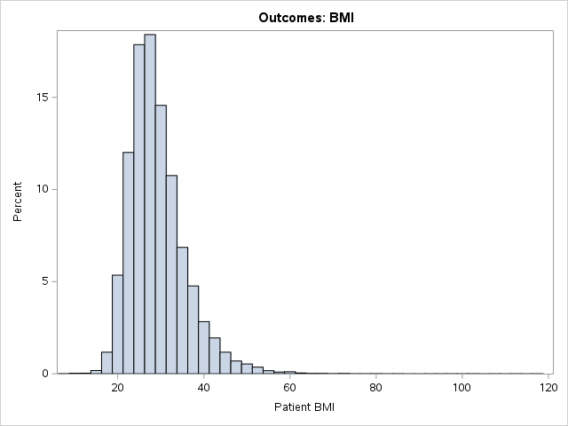

**log**

```
79                                                         The SAS System                      Friday, December 19, 2025 03:04:00 AM

752        ods listing close;ods html5 (id=saspy_internal) file=_tomods1 options(bitmap_mode='inline') device=svg style=HTMLBlue;
752      ! ods graphics on / outputfmt=png;
753
754        PROC SGPLOT DATA = Impt.Outcomes;
755         HISTOGRAM BMI;
756         RUN;
757
758
759        ods html5 (id=saspy_internal) close;ods listing;
760
80                                                         The SAS System                      Friday, December 19, 2025 03:04:00 AM

761
```

BMI is correct.

Top of Tabset

**BMI Category**

#### Create Format

```sas
* Create format for BMI category;
TITLE "Outcomes: BMI Category";
PROC FORMAT;
    VALUE BMIcat
        1= "Underweight"
        2 = "Normal Weight"
        3 = "Overweight"
        4 = "Obese";
    RUN;
```

#### Create Variable

```sas
* Create BMIcat per PI specifications;
DATA Impt.Outcomes;
    SET Impt.Outcomes;
        IF BMI = .         THEN BMIcat = .;
        ELSE IF BMI < 18.5 THEN BMIcat = 1;
        ELSE IF 18.5 <= BMI < 25.0 THEN BMIcat = 2;
        ELSE IF 25.0 <= BMI < 30.0 THEN BMIcat = 3;
        ELSE                            BMIcat = 4;
    ATTRIB BMICat LABEL = "BMI Category" FORMAT = BMIcat.;
    RUN;
```

#### Double Check for Correct Assignment

```sas
* Double check for correct assignment;
PROC PRINT DATA = Impt.Outcomes (OBS = 10);
    VAR BMI BMIcat;
    RUN;
```

**lst**

<!DOCTYPE html>

Outcomes: BMI Category

| Obs | BMI | BMIcat |
| --- | --- | --- |
| 1 | 27.2210 | Overweight |
| 2 | 26.7554 | Overweight |
| 3 | 21.9214 | Normal Weight |
| 4 | 24.5327 | Normal Weight |
| 5 | 22.8914 | Normal Weight |
| 6 | . | . |
| 7 | 20.5234 | Normal Weight |
| 8 | 25.1377 | Overweight |
| 9 | 25.5953 | Overweight |
| 10 | . | . |

**log**

```
85                                                         The SAS System                      Friday, December 19, 2025 03:04:00 AM

801        ods listing close;ods html5 (id=saspy_internal) file=_tomods1 options(bitmap_mode='inline') device=svg style=HTMLBlue;
801      ! ods graphics on / outputfmt=png;
802
803        * Double check for correct assignment;
804        PROC PRINT DATA = Impt.Outcomes (OBS = 10);
805         VAR BMI BMIcat;
806         RUN;
806      !
807
808
809        ods html5 (id=saspy_internal) close;ods listing;
810
86                                                         The SAS System                      Friday, December 19, 2025 03:04:00 AM

811
```

Top of Tabset

**Covid**

#### Create Format

```sas
* Create format for covid status;
PROC FORMAT;
    VALUE CovidCd
        1 = "Yes"
        2 = "No"
        3 = "Unknown/Refused/Missing";
    RUN;
```

#### Create Variable

```sas
* Create Covid status per PI specifications;
DATA Impt.Outcomes;
    SET Impt.Outcomes;
        IF      COVIDPOS IN(1,3) THEN CovidCd = 1;
        ELSE IF COVIDPOS = 2 THEN CovidCd = 2;
        ELSE                      CovidCd = 3;
    ATTRIB CovidCd LABEL = "Ever had Covid" FORMAT = CovidCd.;
    RUN;
```

#### Double Check for Correct Assignment

```sas
* Double check for correct assignment;
PROC PRINT DATA = Impt.Outcomes (OBS = 10);
    VAR COVIDPOS CovidCd;
    RUN;
```

**lst**

<!DOCTYPE html>

Outcomes: BMI Category

| Obs | COVIDPOS | CovidCd |
| --- | --- | --- |
| 1 | 2 | No |
| 2 | 2 | No |
| 3 | 2 | No |
| 4 | 2 | No |
| 5 | 2 | No |
| 6 | 2 | No |
| 7 | 2 | No |
| 8 | 1 | Yes |
| 9 | 1 | Yes |
| 10 | 2 | No |

**log**

```
91                                                         The SAS System                      Friday, December 19, 2025 03:04:00 AM

847        ods listing close;ods html5 (id=saspy_internal) file=_tomods1 options(bitmap_mode='inline') device=svg style=HTMLBlue;
847      ! ods graphics on / outputfmt=png;
848
849        * Double check for correct assignment;
850        PROC PRINT DATA = Impt.Outcomes (OBS = 10);
851         VAR COVIDPOS CovidCd;
852         RUN;
852      !
853
854
855        ods html5 (id=saspy_internal) close;ods listing;
856
92                                                         The SAS System                      Friday, December 19, 2025 03:04:00 AM

857
```

Top of Tabset

**Cancer**

#### Create Format

```sas
* Create format for cancer status;
PROC FORMAT;
    VALUE CancerCd
        1 = "Yes"
        2 = "No";
    RUN;
```

#### Create Variable

```sas
* Create BMIcat per PI specifications;
DATA Impt.Outcomes;
    SET Impt.Outcomes;
        IF      CNCRDIFF = . THEN CancerCd = 2;
        ELSE IF CNCRDIFF IN(1,2,3,7) THEN CancerCd = 1;
    ATTRIB CancerCd LABEL = "Ever had Cancer" FORMAT = Cancercd.;
    RUN;
```

#### Double Check for Correct Assignment

```sas
* Double check for correct assignment;
PROC PRINT DATA = Impt.Outcomes (OBS = 10);
    VAR CNCRDIFF Cancercd;
    RUN;
```

**lst**

<!DOCTYPE html>

Outcomes: BMI Category

| Obs | CNCRDIFF | CancerCd |
| --- | --- | --- |
| 1 | . | No |
| 2 | . | No |
| 3 | . | No |
| 4 | . | No |
| 5 | . | No |
| 6 | . | No |
| 7 | . | No |
| 8 | . | No |
| 9 | . | No |
| 10 | . | No |

**log**

```
97                                                         The SAS System                      Friday, December 19, 2025 03:04:00 AM

891        ods listing close;ods html5 (id=saspy_internal) file=_tomods1 options(bitmap_mode='inline') device=svg style=HTMLBlue;
891      ! ods graphics on / outputfmt=png;
892
893        * Double check for correct assignment;
894        PROC PRINT DATA = Impt.Outcomes (OBS = 10);
895         VAR CNCRDIFF Cancercd;
896         RUN;
896      !
897
898
899        ods html5 (id=saspy_internal) close;ods listing;
900
98                                                         The SAS System                      Friday, December 19, 2025 03:04:00 AM

901
```

Top of Tabset

**Age at First Cancer**

#### Create Format

```sas
* Create format for cancer age;
TITLE "Outcomes: Cancer Age";
PROC FORMAT;
    VALUE CancerAge
        1 = "0-<15"
        2 = "15-<18"
        3 = "18-<39"
        4 = "40+";
    RUN;
```

#### Create Variable

```sas
* Create cancer age per PI specifications;
DATA Impt.Outcomes;
    SET Impt.Outcomes;
        IF      CNCRAGE IN(., 98, 99) THEN CancerAge = .;
        ELSE IF 0 < CNCRAGE < 15 THEN CancerAge = 1;
        ELSE IF 15 <= CNCRAGE < 18 THEN CancerAge = 2;
        ELSE IF 18 <= CNCRAGE < 39 THEN CancerAge = 3;
        ELSE                            CancerAge = 4;
    ATTRIB CancerAge LABEL = "Age at first cancer diagnosis" FORMAT = CancerAge.;
    RUN;
```

#### Double Check for Correct Assignment

```sas
* Double check for correct assignment;
PROC SORT DATA = Impt.Outcomes OUT = Impt.Sorted_Data;
    BY DESCENDING CancerAge;
    RUN;

PROC PRINT DATA = Impt.Sorted_Data (OBS = 10);
    VAR CNCRAGE CancerAge;
    RUN;
```

**lst**

<!DOCTYPE html>

Outcomes: Cancer Age

| Obs | CNCRAGE | CancerAge |
| --- | --- | --- |
| 1 | 70 | 40+ |
| 2 | 71 | 40+ |
| 3 | 75 | 40+ |
| 4 | 69 | 40+ |
| 5 | 45 | 40+ |
| 6 | 57 | 40+ |
| 7 | 50 | 40+ |
| 8 | 80 | 40+ |
| 9 | 66 | 40+ |
| 10 | 60 | 40+ |

**log**

```
103                                                        The SAS System                      Friday, December 19, 2025 03:04:00 AM

941        ods listing close;ods html5 (id=saspy_internal) file=_tomods1 options(bitmap_mode='inline') device=svg style=HTMLBlue;
941      ! ods graphics on / outputfmt=png;
942
943        * Double check for correct assignment;
944        PROC SORT DATA = Impt.Outcomes OUT = Impt.Sorted_Data;
945         BY DESCENDING CancerAge;
946         RUN;
947
948        PROC PRINT DATA = Impt.Sorted_Data (OBS = 10);
949         VAR CNCRAGE CancerAge;
950         RUN;
950      !
951
952
953        ods html5 (id=saspy_internal) close;ods listing;
954
104                                                        The SAS System                      Friday, December 19, 2025 03:04:00 AM

955
```

Top of Tabset

## Consolidate Outcomes Data Set

Here we will collect only the variables we created which the investigator asked for, and the variables needed for the final merge.

#### Collect Variables

```sas
TITLE "Outcomes: Final Data Set";
DATA Impt.Outcomes_Final;
    SET Impt.Outcomes;
    KEEP SEQNO CHDattackCd AsthmaCd BMI BMIcat CovidCd CancerCd CancerAge;
    RENAME  CHDattackCd = CHDattack
            AsthmaCd = Asthma
            CovidCd = Covid
            CancerCd = Cancer;
    RUN;
```

#### View Data

```sas
* Print head;
PROC PRINT DATA = Impt.Outcomes_Final (OBS = 10);
    RUN;

* Double check formats;
ODS SELECT VARIABLES;
PROC CONTENTS DATA = Impt.Outcomes_Final;
    RUN;
```

**lst**

<!DOCTYPE html>

Outcomes: Final Data Set

| Obs | SEQNO | CHDattack | Asthma | BMI | BMIcat | Covid | Cancer | CancerAge |
| --- | --- | --- | --- | --- | --- | --- | --- | --- |
| 1 | 2022000075 | No | Never | 27.2210 | Overweight | No | No | . |
| 2 | 2022000076 | No | Never | 26.7554 | Overweight | No | No | . |
| 3 | 2022000077 | No | Former | 21.9214 | Normal Weight | No | No | . |
| 4 | 2022000078 | No | Never | 24.5327 | Normal Weight | No | No | . |
| 5 | 2022000079 | No | Never | 22.8914 | Normal Weight | No | No | . |
| 6 | 2022000080 | No | Never | . | . | No | No | . |
| 7 | 2022000081 | Yes | Never | 20.5234 | Normal Weight | No | No | . |
| 8 | 2022000082 | Yes | Never | 25.1377 | Overweight | Yes | No | . |
| 9 | 2022000083 | No | Never | 25.5953 | Overweight | Yes | No | . |
| 10 | 2022000084 | No | Current | . | . | No | No | . |

Outcomes: Final Data Set

The CONTENTS Procedure

| Alphabetic List of Variables and Attributes # | Alphabetic List of Variables and Attributes Variable | Alphabetic List of Variables and Attributes Type | Alphabetic List of Variables and Attributes Len | Alphabetic List of Variables and Attributes Format | Alphabetic List of Variables and Attributes Informat | Alphabetic List of Variables and Attributes Label |
| --- | --- | --- | --- | --- | --- | --- |
| 3 | Asthma | Num | 8 | ASTHMACD. |  | Asthma Status |
| 4 | BMI | Num | 8 |  |  | Patient BMI |
| 5 | BMIcat | Num | 8 | BMICAT. |  | BMI Category |
| 2 | CHDattack | Num | 8 | CHDATTACKCD. |  | CHD or Heart Attack |
| 7 | Cancer | Num | 8 | CANCERCD. |  | Ever had Cancer |
| 8 | CancerAge | Num | 8 | CANCERAGE. |  | Age at first cancer diagnosis |
| 6 | Covid | Num | 8 | COVIDCD. |  | Ever had Covid |
| 1 | SEQNO | Num | 8 | BEST12. | BEST32. |  |

**log**

```
107                                                        The SAS System                      Friday, December 19, 2025 03:04:00 AM

976        ods listing close;ods html5 (id=saspy_internal) file=_tomods1 options(bitmap_mode='inline') device=svg style=HTMLBlue;
976      ! ods graphics on / outputfmt=png;
977
978        * Print head;
979        PROC PRINT DATA = Impt.Outcomes_Final (OBS = 10);
980         RUN;
981
982        * Double check formats;
983        ODS SELECT VARIABLES;
984        PROC CONTENTS DATA = Impt.Outcomes_Final;
985         RUN;
986
987
988        ods html5 (id=saspy_internal) close;ods listing;
989
108                                                        The SAS System                      Friday, December 19, 2025 03:04:00 AM

990
```

# Step 5: Create Risk Factors Data Set

**Physical Health**

#### Create Variable

```sas
* Create physical health variable per PI specifications;
TITLE "Risk Factors: Physical Health Not Good";
DATA Impt.Risk;
    SET Impt.Risk;
    IF      PHYSHLTH IN(.,77,99) THEN PhysHealth = .;
    ELSE IF PHYSHLTH = 88        THEN PhysHealth  = 0;
    ELSE                              PhysHealth = (PHYSHLTH /30) * 100;
    LABEL PhysHealth = "Percent of 30 days with physical health not good";
    RUN;
```

#### Double Check for Correct Assignment

```sas
* Double check for correct assignment;
PROC PRINT DATA = Impt.Risk (OBS = 10);
    VAR PHYSHLTH PhysHealth;
    RUN;
```

**lst**

<!DOCTYPE html>

Risk Factors: Physical Health Not Good

| Obs | PHYSHLTH | PhysHealth |
| --- | --- | --- |
| 1 | 88 | 0.00000 |
| 2 | 88 | 0.00000 |
| 3 | 2 | 6.66667 |
| 4 | 88 | 0.00000 |
| 5 | 2 | 6.66667 |
| 6 | 1 | 3.33333 |
| 7 | 88 | 0.00000 |
| 8 | 88 | 0.00000 |
| 9 | 88 | 0.00000 |
| 10 | 1 | 3.33333 |

**log**

```
111                                                        The SAS System                      Friday, December 19, 2025 03:04:00 AM

1011       ods listing close;ods html5 (id=saspy_internal) file=_tomods1 options(bitmap_mode='inline') device=svg style=HTMLBlue;
1011     ! ods graphics on / outputfmt=png;
1012
1013       * Double check for correct assignment;
1014       PROC PRINT DATA = Impt.Risk (OBS = 10);
1015        VAR PHYSHLTH PhysHealth;
1016        RUN;
1017
1018
1019       ods html5 (id=saspy_internal) close;ods listing;
1020
112                                                        The SAS System                      Friday, December 19, 2025 03:04:00 AM

1021
```

Top of Tabset

**Mental Health**

#### Create Variable

```sas
* Create mental health variable per PI specifications;
TITLE "Risk Factors: Mental Health Not Good";
DATA Impt.Risk;
    SET Impt.Risk;
    IF      MENTHLTH IN(.,77,99) THEN MentHealth = .;
    ELSE IF MENTHLTH = 88        THEN MentHealth  = 0;
    ELSE                              MentHealth = (MENTHLTH /30) * 100;
    LABEL MentHealth = "Percent of 30 days with mental health not good";
    RUN;
```

#### Double Check for Correct Assignent

```sas
* Double check for correct assignment;
PROC PRINT DATA = Impt.Risk (OBS = 10);
    VAR MENTHLTH MentHealth;
    RUN;
```

**lst**

<!DOCTYPE html>

Risk Factors: Mental Health Not Good

| Obs | MENTHLTH | MentHealth |
| --- | --- | --- |
| 1 | 88 | 0 |
| 2 | 88 | 0 |
| 3 | 3 | 10 |
| 4 | 88 | 0 |
| 5 | 88 | 0 |
| 6 | 88 | 0 |
| 7 | 88 | 0 |
| 8 | 88 | 0 |
| 9 | 88 | 0 |
| 10 | 88 | 0 |

**log**

```
115                                                        The SAS System                      Friday, December 19, 2025 03:04:00 AM

1042       ods listing close;ods html5 (id=saspy_internal) file=_tomods1 options(bitmap_mode='inline') device=svg style=HTMLBlue;
1042     ! ods graphics on / outputfmt=png;
1043
1044       * Double check for correct assignment;
1045       PROC PRINT DATA = Impt.Risk (OBS = 10);
1046        VAR MENTHLTH MentHealth;
1047        RUN;
1048
1049
1050       ods html5 (id=saspy_internal) close;ods listing;
1051
116                                                        The SAS System                      Friday, December 19, 2025 03:04:00 AM

1052
```

Top of Tabset

**Smoking Status**

#### Create Format

```sas
* Create format for smoking status;
TITLE "Risk Factors: Smoking Status";
PROC FORMAT;
    VALUE SmokeStat
        1 = "Current Smoker"
        2 = "Former Smoker"
        3 = "Never Smoker"
        4 = "Don't Know/Refused/Missing";
    RUN;
```

#### Create Variable

```sas
* Create smoking status variable per PI specifications;
DATA Impt.Risk;
    SET Impt.Risk;
        IF       SMOKE100 = 1 AND SMOKDAY2 IN(1,2) THEN SmokeStat = 1;
        ELSE IF  SMOKE100 = 1 AND SMOKDAY2 = 3     THEN SmokeStat = 2;
        ELSE IF  SMOKE100 = 2                      THEN SmokeStat = 3;
        ELSE                                            SmokeStat = 4;
        ATTRIB SmokeStat LABEL = "Smoking Status" FORMAT = SmokeStat.;
    RUN;
```

#### Double Check for Correct Assignment

```sas
* Double check for correct assignment;
PROC PRINT DATA = Impt.Risk (OBS = 10);
    VAR SMOKE100 SMOKDAY2 SmokeStat;
    RUN;
```

**lst**

<!DOCTYPE html>

Risk Factors: Smoking Status

| Obs | SMOKE100 | SMOKDAY2 | SmokeStat |
| --- | --- | --- | --- |
| 1 | 2 | . | Never Smoker |
| 2 | 2 | . | Never Smoker |
| 3 | 2 | . | Never Smoker |
| 4 | 1 | 2 | Current Smoker |
| 5 | 2 | . | Never Smoker |
| 6 | 2 | . | Never Smoker |
| 7 | 1 | 3 | Former Smoker |
| 8 | 2 | . | Never Smoker |
| 9 | 1 | 3 | Former Smoker |
| 10 | 2 | . | Never Smoker |

**log**

```
121                                                        The SAS System                      Friday, December 19, 2025 03:04:00 AM

1091       ods listing close;ods html5 (id=saspy_internal) file=_tomods1 options(bitmap_mode='inline') device=svg style=HTMLBlue;
1091     ! ods graphics on / outputfmt=png;
1092
1093       * Double check for correct assignment;
1094       PROC PRINT DATA = Impt.Risk (OBS = 10);
1095        VAR SMOKE100 SMOKDAY2 SmokeStat;
1096        RUN;
1097
1098
1099       ods html5 (id=saspy_internal) close;ods listing;
1100
122                                                        The SAS System                      Friday, December 19, 2025 03:04:00 AM

1101
```

Top of Tabset

**Years Smoked**

#### Create Variable

```sas
* Create smoking status variable per PI specifications;
DATA Impt.Risk;
    SET Impt.Risk;

        IF      SmokeStat = 4 THEN SmokeTime = .;
        ELSE IF SmokeStat = 3 THEN SmokeTime = 0;
        ELSE IF SmokeStat IN(1,2) AND LCSFIRST NOT IN(777,999) AND LCSLAST NOT IN(777,999)
            THEN SmokeTime = LCSLAST - LCSFIRST;
        ELSE                        SmokeTime = .;
    ATTRIB SmokeTime LABEL = "How many years smoked";
    RUN;
```

#### Double Check for Correct Assignment

```sas
* Double check for correct assignment;
PROC PRINT DATA = Impt.Risk (OBS = 10);
    VAR SmokeStat LCSFIRST LCSLAST SmokeTime;
    RUN;
```

**lst**

<!DOCTYPE html>

Risk Factors: Smoking Status

| Obs | SmokeStat | LCSFIRST | LCSLAST | SmokeTime |
| --- | --- | --- | --- | --- |
| 1 | Never Smoker | . | . | 0 |
| 2 | Never Smoker | . | . | 0 |
| 3 | Never Smoker | . | . | 0 |
| 4 | Current Smoker | 17 | 999 | . |
| 5 | Never Smoker | . | . | 0 |
| 6 | Never Smoker | . | . | 0 |
| 7 | Former Smoker | 16 | 58 | 42 |
| 8 | Never Smoker | . | . | 0 |
| 9 | Former Smoker | 20 | 21 | 1 |
| 10 | Never Smoker | . | . | 0 |

**log**

```
125                                                        The SAS System                      Friday, December 19, 2025 03:04:00 AM

1124       ods listing close;ods html5 (id=saspy_internal) file=_tomods1 options(bitmap_mode='inline') device=svg style=HTMLBlue;
1124     ! ods graphics on / outputfmt=png;
1125
1126       * Double check for correct assignment;
1127       PROC PRINT DATA = Impt.Risk (OBS = 10);
1128        VAR SmokeStat LCSFIRST LCSLAST SmokeTime;
1129        RUN;
1130
1131
1132       ods html5 (id=saspy_internal) close;ods listing;
1133
126                                                        The SAS System                      Friday, December 19, 2025 03:04:00 AM

1134
```

Note: there is a current smoker with 999 for last cigarette smoked. This was not reported in the data dictionary, but we will assume these are patients that did not wish to report their age.

Top of Tabset

**Alcohol**

#### Create Format

```sas
* Create format for smoking status;
TITLE "Risk Factors: Alcohol";
PROC FORMAT;
    VALUE Alcohol
        1 = "Yes"
        2 = "No";
    RUN;
```

#### Create Variable

```sas
* Create alcohol consumption variable per PI specifications;
DATA Impt.Risk;
    SET Impt.Risk;
        IF      ALCDAY4 IN(., 777,999) THEN Alcohol = .;
        ELSE IF ALCDAY4 = 888 THEN Alcohol = 2;
        ELSE                       Alcohol = 1;
    ATTRIB Alcohol LABEL = "Consumed alcohol in past 30 days" FORMAT = Alcohol.;
    RUN;
```

#### Double Check for Correct Assignment

```sas
* Double check for correct assignment;
PROC PRINT DATA = Impt.Risk (OBS = 10);
    VAR ALCDAY4 Alcohol;
    RUN;
```

**lst**

<!DOCTYPE html>

Risk Factors: Alcohol

| Obs | ALCDAY4 | Alcohol |
| --- | --- | --- |
| 1 | 888 | No |
| 2 | 888 | No |
| 3 | 888 | No |
| 4 | 888 | No |
| 5 | 203 | Yes |
| 6 | 888 | No |
| 7 | 205 | Yes |
| 8 | 888 | No |
| 9 | 888 | No |
| 10 | 201 | Yes |

**log**

```
131                                                        The SAS System                      Friday, December 19, 2025 03:04:00 AM

1170       ods listing close;ods html5 (id=saspy_internal) file=_tomods1 options(bitmap_mode='inline') device=svg style=HTMLBlue;
1170     ! ods graphics on / outputfmt=png;
1171
1172       * Double check for correct assignment;
1173       PROC PRINT DATA = Impt.Risk (OBS = 10);
1174        VAR ALCDAY4 Alcohol;
1175        RUN;
1176
1177
1178       ods html5 (id=saspy_internal) close;ods listing;
1179
132                                                        The SAS System                      Friday, December 19, 2025 03:04:00 AM

1180
```

Top of Tabset

**Months Between Covid Vaccines**

#### Create Format

```sas
* Create covid vaccine variable per PI specifications;
DATA Impt.Risk;
  SET Impt.Risk;
  * Convert dates to a character string;
  firstvax_char = TRIM(LEFT(PUT(COVIDFS1, 6.)));
  secondvax_char = TRIM(LEFT(PUT(COVIDSE1, 6.)));

  * Extract Month and Year for firstvax_char;
  IF LENGTH(firstvax_char) = 5 THEN DO;
    month1 = INPUT(SUBSTR(firstvax_char, 1, 1), BEST12.);
    year1 = INPUT(SUBSTR(firstvax_char, 2), BEST12.);
  END;
  ELSE IF LENGTH(firstvax_char) = 6 THEN DO;
    month1 = INPUT(SUBSTR(firstvax_char, 1, 2), BEST12.);
    year1 = INPUT(SUBSTR(firstvax_char, 3), BEST12.);
  END;

  * Extract Month and Year for secondvax_char;
  IF LENGTH(secondvax_char) = 5 THEN DO;
    month2 = INPUT(SUBSTR(secondvax_char, 1, 1), BEST12.);
    year2 = INPUT(SUBSTR(secondvax_char, 2), BEST12.);
  END;
  ELSE IF LENGTH(secondvax_char) = 6 THEN DO;
    month2 = INPUT(SUBSTR(secondvax_char, 1, 2), BEST12.);
    year2 = INPUT(SUBSTR(secondvax_char, 3), BEST12.);
  END;

    * Calculate number of months inbetween;
    IF SUBSTR(firstvax_char, 1, 2) NOT IN("77" "99")
    AND SUBSTR(Secondvax_char,1, 2) NOT IN ("77", "99")
    THEN DO
  date1 = MDY(month1, 1, year1);
  date2 = MDY(month2, 1, year2);

  * Calculate the difference in months;
  CovidVaxMonths = INTCK('MONTH', date1, date2);
  ATTRIB CovidVaxMonths Label = "Number of months between first and second covid vaccination";
  END;

  RUN;
```

#### Double Check for Correct Calculations

```sas
* Double check calculations are correct;
PROC SORT DATA=Impt.Risk OUT=Impt.SortedRisk;
  BY DESCENDING CovidVaxMonths;
RUN;
PROC PRINT DATA = Impt.SortedRisk (OBS = 10);
    VAR month1 year1 month2 year2 CovidVaxMonths;
    RUN;
```

**lst**

<!DOCTYPE html>

Risk Factors: Alcohol

| Obs | month1 | year1 | month2 | year2 | CovidVaxMonths |
| --- | --- | --- | --- | --- | --- |
| 1 | 2 | 2020 | 12 | 2022 | 34 |
| 2 | 2 | 2020 | 12 | 2022 | 34 |
| 3 | 3 | 2020 | 11 | 2022 | 32 |
| 4 | 4 | 2019 | 12 | 2021 | 32 |
| 5 | 3 | 2020 | 10 | 2022 | 31 |
| 6 | 3 | 2020 | 10 | 2022 | 31 |
| 7 | 6 | 2020 | 12 | 2022 | 30 |
| 8 | 4 | 2020 | 10 | 2022 | 30 |
| 9 | 1 | 2020 | 7 | 2022 | 30 |
| 10 | 5 | 2020 | 11 | 2022 | 30 |

**log**

```
135                                                        The SAS System                      Friday, December 19, 2025 03:04:00 AM

1232       ods listing close;ods html5 (id=saspy_internal) file=_tomods1 options(bitmap_mode='inline') device=svg style=HTMLBlue;
1232     ! ods graphics on / outputfmt=png;
1233
1234       * Double check calculations are correct;
1235       PROC SORT DATA=Impt.Risk OUT=Impt.SortedRisk;
1236         BY DESCENDING CovidVaxMonths;
1237       RUN;
1238       PROC PRINT DATA = Impt.SortedRisk (OBS = 10);
1239        VAR month1 year1 month2 year2 CovidVaxMonths;
1240        RUN;
1241
1242
1243       ods html5 (id=saspy_internal) close;ods listing;
1244
136                                                        The SAS System                      Friday, December 19, 2025 03:04:00 AM

1245
```

Top of Tabset

**Marijuana Percent**

#### Create Variable

```sas
* Create Marijuana percent variable per PI specifications;
TITLE "Risk Factors: Marijuana Percentage";
DATA Impt.Risk;
    SET Impt.Risk;
    IF      MARIJAN1 IN(.,77,99) THEN MarijuanaPerc = .;
    ELSE IF MARIJAN1 = 88        THEN MarijuanaPerc  = 0;
    ELSE                              MarijuanaPerc = (MARIJAN1 /30) * 100;
    LABEL MarijuanaPerc = "Percent of 30 days with marijuana use";
    RUN;
```

#### Double Check for Correct Assignment

```sas
* Double check for correct assignment;
PROC SORT DATA=Impt.Risk OUT=Impt.SortedRisk;
  BY DESCENDING MarijuanaPerc;
RUN;
PROC PRINT DATA = Impt.SortedRisk (OBS = 10);
    VAR MARIJAN1 MarijuanaPerc;
    RUN;
```

**lst**

<!DOCTYPE html>

Risk Factors: Marijuana Percentage

| Obs | MARIJAN1 | MarijuanaPerc |
| --- | --- | --- |
| 1 | 30 | 100 |
| 2 | 30 | 100 |
| 3 | 30 | 100 |
| 4 | 30 | 100 |
| 5 | 30 | 100 |
| 6 | 30 | 100 |
| 7 | 30 | 100 |
| 8 | 30 | 100 |
| 9 | 30 | 100 |
| 10 | 30 | 100 |

**log**

```
139                                                        The SAS System                      Friday, December 19, 2025 03:04:00 AM

1266       ods listing close;ods html5 (id=saspy_internal) file=_tomods1 options(bitmap_mode='inline') device=svg style=HTMLBlue;
1266     ! ods graphics on / outputfmt=png;
1267
1268       * Double check for correct assignment;
1269       PROC SORT DATA=Impt.Risk OUT=Impt.SortedRisk;
1270         BY DESCENDING MarijuanaPerc;
1271       RUN;
1272       PROC PRINT DATA = Impt.SortedRisk (OBS = 10);
1273        VAR MARIJAN1 MarijuanaPerc;
1274        RUN;
1275
1276
1277       ods html5 (id=saspy_internal) close;ods listing;
1278
140                                                        The SAS System                      Friday, December 19, 2025 03:04:00 AM

1279
```

Top of Tabset

**Marijuana Use**

#### Create Format

```sas
* Create format for Marijuana Use;
TITLE "Risk Factors: Marijuana Use";
PROC FORMAT;
    VALUE Marijuana
        1 = "Yes"
        2 = "No";
    RUN;
```

#### Create Variable

```sas
* Create marijuana use variable per PI specifications;
DATA Impt.Risk;
    SET Impt.Risk;
        IF      MARIJAN1 IN(., 77,99) THEN Marijuana = .;
        ELSE IF MARIJAN1 = 88 THEN Marijuana = 2;
        ELSE                       Marijuana = 1;
    ATTRIB Marijuana LABEL = "Marijuana use in past 30 days" FORMAT = Marijuana.;
    RUN;
```

#### Double Check for Correct Assignment

```sas
* Double check for correct assignment;
PROC SORT DATA=Impt.Risk OUT=Impt.SortedRisk;
  BY DESCENDING Marijuana;
RUN;
PROC PRINT DATA = Impt.SortedRisk (OBS = 10);
    VAR MARIJAN1 Marijuana;
    RUN;
```

**lst**

<!DOCTYPE html>

Risk Factors: Marijuana Use

| Obs | MARIJAN1 | Marijuana |
| --- | --- | --- |
| 1 | 88 | No |
| 2 | 88 | No |
| 3 | 88 | No |
| 4 | 88 | No |
| 5 | 88 | No |
| 6 | 88 | No |
| 7 | 88 | No |
| 8 | 88 | No |
| 9 | 88 | No |
| 10 | 88 | No |

**log**

```
145                                                        The SAS System                      Friday, December 19, 2025 03:04:00 AM

1315       ods listing close;ods html5 (id=saspy_internal) file=_tomods1 options(bitmap_mode='inline') device=svg style=HTMLBlue;
1315     ! ods graphics on / outputfmt=png;
1316
1317       * Double check for correct assignment;
1318       PROC SORT DATA=Impt.Risk OUT=Impt.SortedRisk;
1319         BY DESCENDING Marijuana;
1320       RUN;
1321       PROC PRINT DATA = Impt.SortedRisk (OBS = 10);
1322        VAR MARIJAN1 Marijuana;
1323        RUN;
1324
1325
1326       ods html5 (id=saspy_internal) close;ods listing;
1327
146                                                        The SAS System                      Friday, December 19, 2025 03:04:00 AM

1328
```

Top of Tabset

**Packs of Cigarettes per Day**

#### Create Variable

```sas
* Create Variable;
TITLE "Risk Factors: Number of Cigarette Packs per Day";
DATA Impt.Risk;
    SET Impt.Risk;
        IF      LCSNUMCG IN(777,999) THEN SmokeNum = .;
        ELSE IF LCSNUMCG = .         THEN SmokeNum = .;
        ELSE IF LCSNUMCG = 0         THEN SmokeNum = 0;
        ELSE                              SmokeNum =  LCSNUMCG/20;
    ATTRIB SmokeNum LABEL = "Numer of Cigarette Packs Per Day";
    RUN;
```

#### Double Check for Correct Assignment

```sas
* Double check for correct assignment;
PROC PRINT DATA = Impt.Risk (OBS = 10);
    VAR LCSNUMCG SmokeNum;
    RUN;
```

**lst**

<!DOCTYPE html>

Risk Factors: Number of Cigarette Packs per Day

| Obs | LCSNUMCG | SmokeNum |
| --- | --- | --- |
| 1 | . | . |
| 2 | . | . |
| 3 | . | . |
| 4 | 2 | 0.10 |
| 5 | . | . |
| 6 | . | . |
| 7 | 35 | 1.75 |
| 8 | . | . |
| 9 | 5 | 0.25 |
| 10 | . | . |

**log**

```
149                                                        The SAS System                      Friday, December 19, 2025 03:04:00 AM

1350       ods listing close;ods html5 (id=saspy_internal) file=_tomods1 options(bitmap_mode='inline') device=svg style=HTMLBlue;
1350     ! ods graphics on / outputfmt=png;
1351
1352       * Double check for correct assignment;
1353       PROC PRINT DATA = Impt.Risk (OBS = 10);
1354        VAR LCSNUMCG SmokeNum;
1355        RUN;
1356
1357
1358       ods html5 (id=saspy_internal) close;ods listing;
1359
150                                                        The SAS System                      Friday, December 19, 2025 03:04:00 AM

1360
```

Top of Tabset

## Consolidate Risk Factors Data Set

Here we will collect only the variables we created which the investigator asked for, and the variables needed for the final merge.

#### Collect Variables

```sas
TITLE "Risk Factors: Final Data Set";
DATA Impt.Risk_Final;
    SET Impt.Risk;
    KEEP id PhysHealth MentHealth SmokeStat SmokeNum SmokeTime Alcohol CovidVaxMonths MarijuanaPerc Marijuana;
    RUN;
```

#### View the Data Set

```sas
* Print head;
PROC PRINT DATA = Impt.Risk_Final (OBS = 10);
    RUN;

* Double check formats;
TITLE "Risk Factors: Check Formats";
ODS SELECT VARIABLES;
PROC CONTENTS DATA = Impt.Risk_Final;
    RUN;
```

**lst**

<!DOCTYPE html>

Risk Factors: Final Data Set

| Obs | id | PhysHealth | MentHealth | SmokeStat | SmokeTime | Alcohol | CovidVaxMonths | MarijuanaPerc | Marijuana | SmokeNum |
| --- | --- | --- | --- | --- | --- | --- | --- | --- | --- | --- |
| 1 | 1_2022000001 | 0.00000 | 0 | Never Smoker | 0 | No | . | . | . | . |
| 2 | 1_2022000002 | 0.00000 | 0 | Never Smoker | 0 | No | . | . | . | . |
| 3 | 1_2022000003 | 6.66667 | 10 | Never Smoker | 0 | No | . | . | . | . |
| 4 | 1_2022000004 | 0.00000 | 0 | Current Smoker | . | No | . | . | . | 0.10 |
| 5 | 1_2022000005 | 6.66667 | 0 | Never Smoker | 0 | Yes | . | . | . | . |
| 6 | 1_2022000006 | 3.33333 | 0 | Never Smoker | 0 | No | . | . | . | . |
| 7 | 1_2022000007 | 0.00000 | 0 | Former Smoker | 42 | Yes | . | . | . | 1.75 |
| 8 | 1_2022000008 | 0.00000 | 0 | Never Smoker | 0 | No | . | . | . | . |
| 9 | 1_2022000009 | 0.00000 | 0 | Former Smoker | 1 | No | . | . | . | 0.25 |
| 10 | 1_2022000010 | 3.33333 | 0 | Never Smoker | 0 | Yes | . | . | . | . |

Risk Factors: Check Formats

The CONTENTS Procedure

| Alphabetic List of Variables and Attributes # | Alphabetic List of Variables and Attributes Variable | Alphabetic List of Variables and Attributes Type | Alphabetic List of Variables and Attributes Len | Alphabetic List of Variables and Attributes Format | Alphabetic List of Variables and Attributes Informat | Alphabetic List of Variables and Attributes Label |
| --- | --- | --- | --- | --- | --- | --- |
| 6 | Alcohol | Num | 8 | ALCOHOL. |  | Consumed alcohol in past 30 days |
| 7 | CovidVaxMonths | Num | 8 |  |  | Number of months between first and second covid vaccination |
| 9 | Marijuana | Num | 8 | MARIJUANA. |  | Marijuana use in past 30 days |
| 8 | MarijuanaPerc | Num | 8 |  |  | Percent of 30 days with marijuana use |
| 3 | MentHealth | Num | 8 |  |  | Percent of 30 days with mental health not good |
| 2 | PhysHealth | Num | 8 |  |  | Percent of 30 days with physical health not good |
| 10 | SmokeNum | Num | 8 |  |  | Numer of Cigarette Packs Per Day |
| 4 | SmokeStat | Num | 8 | SMOKESTAT. |  | Smoking Status |
| 5 | SmokeTime | Num | 8 |  |  | How many years smoked |
| 1 | id | Char | 13 | $13. | $13. | id |

**log**

```
153                                                        The SAS System                      Friday, December 19, 2025 03:04:00 AM

1377       ods listing close;ods html5 (id=saspy_internal) file=_tomods1 options(bitmap_mode='inline') device=svg style=HTMLBlue;
1377     ! ods graphics on / outputfmt=png;
1378
1379       * Print head;
1380       PROC PRINT DATA = Impt.Risk_Final (OBS = 10);
1381        RUN;
1382
1383       * Double check formats;
1384       TITLE "Risk Factors: Check Formats";
1385       ODS SELECT VARIABLES;
1386       PROC CONTENTS DATA = Impt.Risk_Final;
1387        RUN;
1388
1389
1390       ods html5 (id=saspy_internal) close;ods listing;
1391
154                                                        The SAS System                      Friday, December 19, 2025 03:04:00 AM

1392
```

# Step 6: Create Reference Table

We just need to make one simple change to this data set: aggregate `Month`, `Day`, and `Year` into a date object in SAS.

## Create `Date` Variable in Reference Table

#### Create Variable

```sas
* Create and Format date variable;
DATA Impt.Ref_Final;
    SET Impt.ref_table_long;
    IntvDate = MDY(IMONTH, IDAY, IYEAR);
    ATTRIB IntvDate LABEL = "Interview Date" FORMAT = MMDDYY10.;
    KEEP id SEQNO IntvDate;
    RUN;
```

#### Double Check for Correct Conversion

```sas
* Double check by printing;
PROC PRINT DATA = Impt.Ref_Final (OBS = 10);
    RUN;
```

**lst**

<!DOCTYPE html>

Risk Factors: Check Formats

| Obs | id | SEQNO | IntvDate |
| --- | --- | --- | --- |
| 1 | 6_2022000075 | 2022000075 | 07/05/2022 |
| 2 | 6_2022000076 | 2022000076 | 06/28/2022 |
| 3 | 6_2022000077 | 2022000077 | 06/27/2022 |
| 4 | 6_2022000078 | 2022000078 | 06/29/2022 |
| 5 | 6_2022000079 | 2022000079 | 07/05/2022 |
| 6 | 6_2022000080 | 2022000080 | 07/05/2022 |
| 7 | 6_2022000081 | 2022000081 | 07/09/2022 |
| 8 | 6_2022000082 | 2022000082 | 06/28/2022 |
| 9 | 6_2022000083 | 2022000083 | 07/04/2022 |
| 10 | 6_2022000084 | 2022000084 | 07/09/2022 |

**log**

```
157                                                        The SAS System                      Friday, December 19, 2025 03:04:00 AM

1411       ods listing close;ods html5 (id=saspy_internal) file=_tomods1 options(bitmap_mode='inline') device=svg style=HTMLBlue;
1411     ! ods graphics on / outputfmt=png;
1412
1413       * Double check by printing;
1414       PROC PRINT DATA = Impt.Ref_Final (OBS = 10);
1415        RUN;
1416
1417
1418       ods html5 (id=saspy_internal) close;ods listing;
1419
158                                                        The SAS System                      Friday, December 19, 2025 03:04:00 AM

1420
```

# Step 7: Merge Data Sets

Before we can merge, we need to ensure the variable we will merge on is the same format and type across all data sets.

In particular, SEQNO in the demographics Final data set is a character variable with ’-’s in it. We have to clean those out and make it numeric to merge it using the reference table.

## Merge Reference Table, Demographics, and Outcomes on SEQNO

#### Ensure Same Format and Type for SEQNO

```sas
* Convert SEQNO in the reference table to numeric and SORT;
TITLE "Final Data Set";
DATA Impt.Ref_Final;
    SET Impt.Ref_Final;
    SEQNO_num = INPUT(SEQNO, BEST12.);
    FORMAT SEQNO_num BEST12.;
    DROP SEQNO;
    RENAME SEQNO_NUM = SEQNO;
    RUN;


* Correct the SEQNO format in the demographics data set;
DATA Impt.Demographics_Final;
    SET Impt.Demographics_Final;
    SEQNO = COMPRESS(SEQNO, "-");
    SEQNO_num = INPUT(SEQNO, BEST12.);
    FORMAT SEQNO_num BEST12.;
    DROP SEQNO;
    RENAME SEQNO_num = SEQNO;
    RUN;
```

#### Sort Data Sets

```sas
* Sort Demographics_Final by SEQNO;
PROC SORT DATA = Impt.Demographics_Final;
    BY SEQNO;
    RUN;

* Sort Outcomes_Final by SEQNO;
PROC SORT DATA = Impt.Outcomes_Final;
    BY SEQNO;
    RUN;

* Sort Ref_Final by SEQNO;
PROC SORT DATA = Impt.Ref_Final;
    BY SEQNO;
    RUN;
```

#### Perform Merge on SEQNO

```sas
* First merge by SEQNO;
DATA Impt.BRFSS_Final;
    MERGE Impt.Demographics_Final (IN = a)
          Impt.Ref_Final (IN = b)
          Impt.Outcomes_Final (IN = c);
    BY SEQNO;
    IF a AND b AND c;
    RUN;
```

## Merge Risk Factors on ID

#### Sort by ID

```sas
* Sort by ID;
PROC SORT DATA = Impt.BRFSS_Final;
    BY id;
    RUN;

* Sort by ID;
PROC SORT DATA = impt.Risk_Final;
    BY id;
    RUN;
```

#### Perform Merge on ID

```sas
* Then merge by Id;
DATA Impt.BRFSS_Final;
    MERGE Impt.BRFSS_Final (IN = a)
          Impt.Risk_Final (IN = b);
    BY id;
    IF a AND b;
    RUN;
```

## Clean Final Data Set

```sas
* Rearrange and drop extraneous variables for a cleaner data set;
DATA Impt.BRFSS_Final;
    RETAIN id SEQNO IntvDate;
    SET Impt.BRFSS_Final;
    DROP SEQNO_OUTCOMES SEQNO_REF SEQNO_DEMO id_RISK id SEQNO;
    ATTRIB SEQNO LABEL = "Sequence Number";
    ATTRIB id LABEL = "ID";
    RUN;
```

# Final Data Set

```sas
* Print top 10 observations;
PROC PRINT DATA = Impt.BRFSS_Final (OBS = 10);
    RUN;

* Check variable types;
PROC CONTENTS DATA = Impt.BRFSS_Final;
    RUN;
```

**lst**

<!DOCTYPE html>

Final Data Set

| Obs | IntvDate | Race | Insurance | Education | Age | Income | Disabilities | CHDattack | Asthma | BMI | BMIcat | Covid | Cancer | CancerAge | PhysHealth | MentHealth | SmokeStat | SmokeTime | Alcohol | CovidVaxMonths | MarijuanaPerc | Marijuana | SmokeNum |
| --- | --- | --- | --- | --- | --- | --- | --- | --- | --- | --- | --- | --- | --- | --- | --- | --- | --- | --- | --- | --- | --- | --- | --- |
| 1 | 07/14/2022 | Non-Hispanic White | Private/commercial/Medicare/Medigap | 4+ Year College Degree | 18-44 | 50k-<100k | 0 | No | Never | 18.3995 | Underweight | No | No | . | 0.000 | 0.000 | Never Smoker | 0 | Yes | . | . | . | . |
| 2 | 08/10/2022 | Non-Hispanic Black | Private/commercial/Medicare/Medigap | Some College | 45-64 | <15k | 4 | No | Never | 32.1991 | Obese | Yes | No | . | 100.000 | 100.000 | Never Smoker | 0 | No | . | . | . | . |
| 3 | 02/16/2022 | Other | Private/commercial/Medicare/Medigap | 4+ Year College Degree | 18-44 | 50k-<100k | 0 | No | Former | 24.2260 | Normal Weight | Yes | No | . | 3.333 | 10.000 | Never Smoker | 0 | Yes | . | . | . | . |
| 4 | 03/02/2022 | Non-Hispanic White | Private/commercial/Medicare/Medigap | Some College | 45-64 | 100k-<200k | 0 | No | Never | . | . | Unknown/Refused/Missing | No | . | 0.000 | 0.000 | Don't Know/Refused/Missing | . | . | . | . | . | . |
| 5 | 02/24/2022 | Other | Private/commercial/Medicare/Medigap | Graduated High School | 18-44 | . | 0 | No | Current | 22.1021 | Normal Weight | No | No | . | 6.667 | 83.333 | Never Smoker | 0 | No | . | . | . | . |
| 6 | 02/15/2022 | Non-Hispanic White | Private/commercial/Medicare/Medigap | 4+ Year College Degree | 65+ | . | 0 | Yes | Never | 27.1393 | Overweight | Yes | No | . | 0.000 | 0.000 | Never Smoker | 0 | Yes | . | . | . | . |
| 7 | 04/03/2022 | Non-Hispanic White | Private/commercial/Medicare/Medigap | 4+ Year College Degree | 45-64 | 50k-<100k | 0 | No | Never | 24.7945 | Normal Weight | No | No | . | 0.000 | 0.000 | Never Smoker | 0 | No | . | . | . | . |
| 8 | 03/21/2022 | Non-Hispanic White | Private/commercial/Medicare/Medigap | Some College | 45-64 | 15-<35k | 5 | Yes | Never | 25.4475 | Overweight | Unknown/Refused/Missing | No | . | 100.000 | 100.000 | Don't Know/Refused/Missing | . | . | . | . | . | . |
| 9 | 03/07/2022 | Non-Hispanic White | Tricare | Some College | 18-44 | 50k-<100k | 1 | No | Never | . | . | No | No | . | 0.000 | 66.667 | Never Smoker | 0 | Yes | . | . | . | . |
| 10 | 03/31/2022 | Hispanic | Private/commercial/Medicare/Medigap | <High School | 65+ | <15k | 1 | No | Never | 23.4619 | Normal Weight | No | No | . | . | 0.000 | Never Smoker | 0 | No | . | . | . | . |

Final Data Set

The CONTENTS Procedure

| Data Set Name | IMPT.BRFSS_FINAL | Observations | 48332 |
| --- | --- | --- | --- |
| Member Type | DATA | Variables | 23 |
| Engine | V9 | Indexes | 0 |
| Created | 12/19/2025 03:06:54 | Observation Length | 184 |
| Last Modified | 12/19/2025 03:06:54 | Deleted Observations | 0 |
| Protection |  | Compressed | NO |
| Data Set Type |  | Sorted | NO |
| Label |  |  |  |
| Data Representation | SOLARIS_X86_64, LINUX_X86_64, ALPHA_TRU64, LINUX_IA64 |  |  |
| Encoding | utf-8 Unicode (UTF-8) |  |  |

| Engine/Host Dependent Information |  |
| --- | --- |
| Data Set Page Size | 131072 |
| Number of Data Set Pages | 69 |
| First Data Page | 1 |
| Max Obs per Page | 711 |
| Obs in First Data Page | 682 |
| Number of Data Set Repairs | 0 |
| Filename | /home/u63376223/sasuser.v94/Data Management Using SAS/BRFSS/Data/2_Import/brfss_final.sas7bdat |
| Release Created | 9.0401M8 |
| Host Created | Linux |
| Inode Number | 11143675314 |
| Access Permission | rw-r–r– |
| Owner Name | u63376223 |
| File Size | 9MB |
| File Size (bytes) | 9175040 |

| Alphabetic List of Variables and Attributes # | Alphabetic List of Variables and Attributes Variable | Alphabetic List of Variables and Attributes Type | Alphabetic List of Variables and Attributes Len | Alphabetic List of Variables and Attributes Format | Alphabetic List of Variables and Attributes Label |
| --- | --- | --- | --- | --- | --- |
| 5 | Age | Num | 8 | AGECD. | Age |
| 19 | Alcohol | Num | 8 | ALCOHOL. | Consumed alcohol in past 30 days |
| 9 | Asthma | Num | 8 | ASTHMACD. | Asthma Status |
| 10 | BMI | Num | 8 |  | Patient BMI |
| 11 | BMIcat | Num | 8 | BMICAT. | BMI Category |
| 8 | CHDattack | Num | 8 | CHDATTACKCD. | CHD or Heart Attack |
| 13 | Cancer | Num | 8 | CANCERCD. | Ever had Cancer |
| 14 | CancerAge | Num | 8 | CANCERAGE. | Age at first cancer diagnosis |
| 12 | Covid | Num | 8 | COVIDCD. | Ever had Covid |
| 20 | CovidVaxMonths | Num | 8 |  | Number of months between first and second covid vaccination |
| 7 | Disabilities | Num | 8 | BEST. | Total Number of Disabilities |
| 4 | Education | Num | 8 | EDUCATIONCD. | Education |
| 6 | Income | Num | 8 | INCOMECD. | Income |
| 3 | Insurance | Num | 8 | INSURANCECD. | Insurance |
| 1 | IntvDate | Num | 8 | MMDDYY10. | Interview Date |
| 22 | Marijuana | Num | 8 | MARIJUANA. | Marijuana use in past 30 days |
| 21 | MarijuanaPerc | Num | 8 |  | Percent of 30 days with marijuana use |
| 16 | MentHealth | Num | 8 |  | Percent of 30 days with mental health not good |
| 15 | PhysHealth | Num | 8 |  | Percent of 30 days with physical health not good |
| 2 | Race | Num | 8 | RACECD. | Race |
| 23 | SmokeNum | Num | 8 |  | Numer of Cigarette Packs Per Day |
| 17 | SmokeStat | Num | 8 | SMOKESTAT. | Smoking Status |
| 18 | SmokeTime | Num | 8 |  | How many years smoked |

**log**

```
171                                                        The SAS System                      Friday, December 19, 2025 03:04:00 AM

1543       ods listing close;ods html5 (id=saspy_internal) file=_tomods1 options(bitmap_mode='inline') device=svg style=HTMLBlue;
1543     ! ods graphics on / outputfmt=png;
1544
1545       * Print top 10 observations;
1546       PROC PRINT DATA = Impt.BRFSS_Final (OBS = 10);
1547        RUN;
1548
1549       * Check variable types;
1550       PROC CONTENTS DATA = Impt.BRFSS_Final;
1551        RUN;
1552
1553
1554       ods html5 (id=saspy_internal) close;ods listing;
1555
172                                                        The SAS System                      Friday, December 19, 2025 03:04:00 AM

1556
```